# profilepoint analysis Slope deposits

fabian gruber

October 24, 2017

what are the units with the most confusion? DC 20 CSR 13 CBD 8 Mxd 6 ISR 3 SSR 3

How do those points that were classified correctly by the geologic map differ from those identified by the surveyors?

0 1 65 55 [1] “OBB error with all predictors of allpreds is 0.216666666666667” [1] “OBB error with all predictors of roughness is 0.241666666666667” [1] “OBB error with all predictors of localterrain is 0.316666666666667”

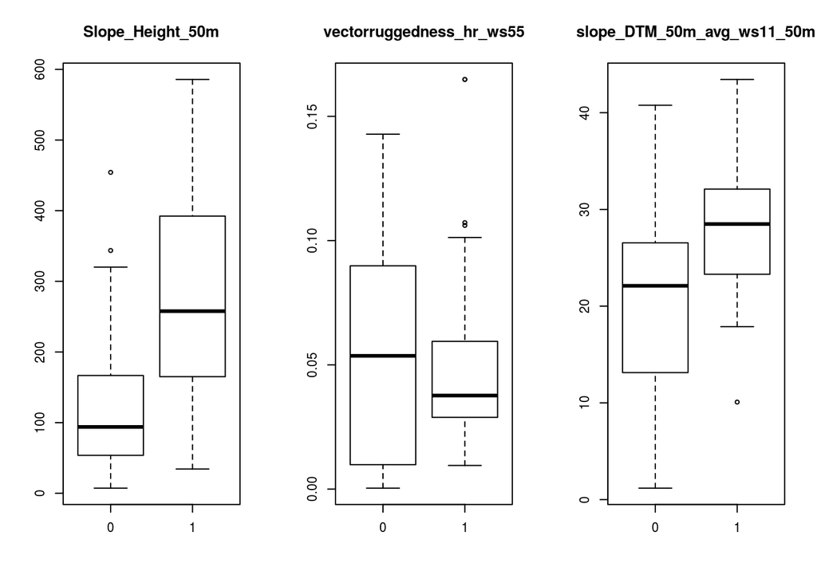

How are these points morphometrically different from others For instance different to Debris cones

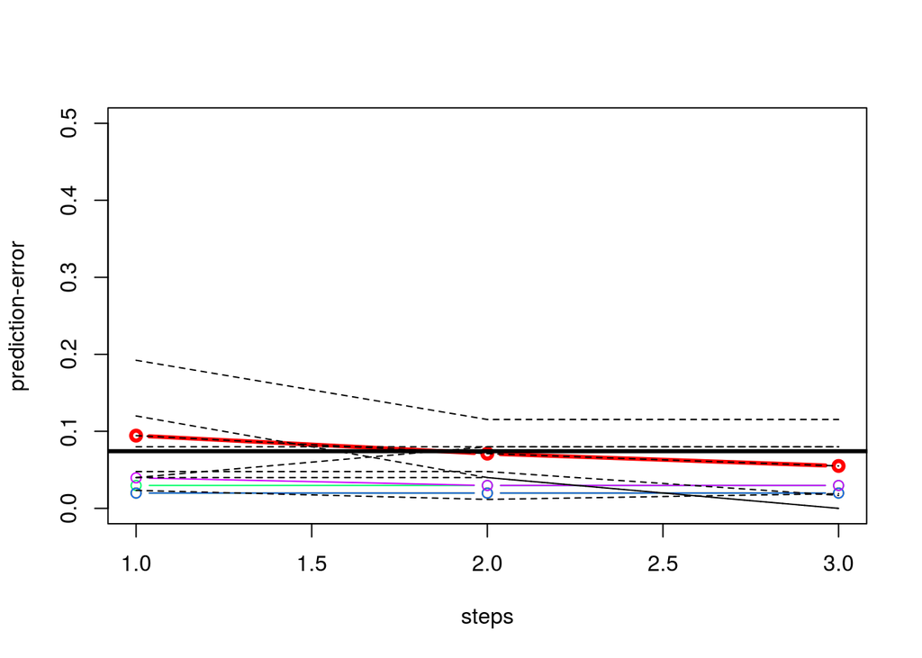

[1] “Prediction error at end is: 0.0944615384615385” [2] “Prediction error at end is: 0.0710769230769231” [3] “Prediction error at end is: 0.0550769230769231”

| k 1 | k 2 | k 3 | k 4 | k 5 |
| --- | --- | --- | --- | --- |
| Relative_Slope_Position_50m | fischerk_ws3_hr | longc_DTM_50m_avg_ws7_50m | longc_DTM_50m_avg_ws7_50m | geom_hr_L3_fl1_rplipedgedensity_UE_hr_20cells_hr |
| Vertical_Distance_to_Channel_Network_50m | vectorstrength_hr_ws3_hr | planc_DTM_50m_avg_ws11_50m | minic_ws15_hr_hr | dtm_hr_CONVEX_r10 |
| crosc_ws15_hr_hr | planc_ws13_hr_hr | profc_DTM_50m_avg_ws9_50m | minic_ws3_hr_hr | fischerk_ws13_hr |

[1] “OBB error with all predictors of allpreds is 0.0476190476190476”

|  | DC | SD | MeanDecreaseAccuracy | MeanDecreaseGini |
| --- | --- | --- | --- | --- |
| Channel_Network_Base_Level_hr | 0.0136667 | 0.0009681 | 0.0015032 | 0.1633450 |
| elev_ws11_10m | 0.0073333 | 0.0010764 | 0.0014102 | 0.1450298 |
| elev_ws15_10m | 0.0060000 | 0.0006837 | 0.0009891 | 0.2031053 |
| elev_ws5_10m | 0.0080000 | 0.0006778 | 0.0009875 | 0.1434501 |
| elev_ws3_10m | 0.0073333 | 0.0006513 | 0.0009298 | 0.0836721 |
| slope_DTM_50m_avg_ws5_50m | 0.0011667 | 0.0008850 | 0.0009258 | 0.0344376 |
| Vertical_Distance_to_Channel_Network_50m | 0.0036667 | 0.0007218 | 0.0009175 | 0.2059699 |
| vectorruggedness_hr_ws27 | 0.0010000 | 0.0008497 | 0.0008727 | 0.0589708 |
| vectorruggedness_hr_ws59 | 0.0036667 | 0.0007418 | 0.0008423 | 0.0377909 |
| Channel_Network_Base_Level_50m | 0.0020000 | 0.0007701 | 0.0008227 | 0.0784588 |

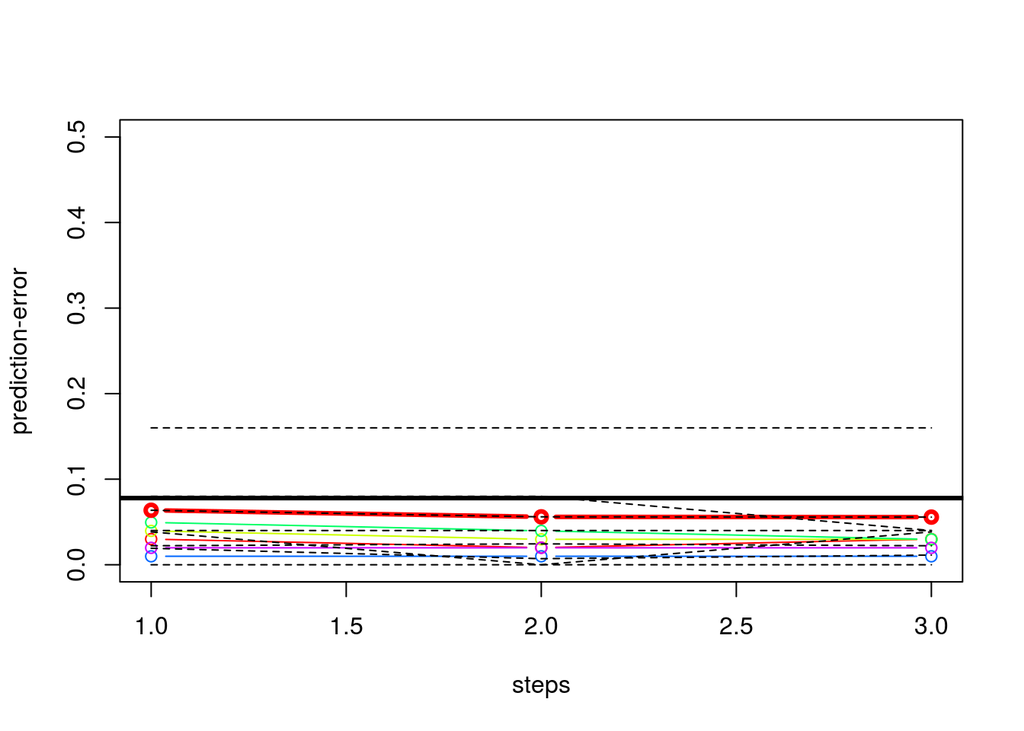

[1] “Prediction error at end is: 0.0636923076923077” [2] “Prediction error at end is: 0.056”  
[3] “Prediction error at end is: 0.0556923076923077”

| k 1 | k 2 | k 3 | k 4 | k 5 |
| --- | --- | --- | --- | --- |
| geom_hr_L3_fl1_rplipmps_UE_hr_20cells_hr | geom_hr_L3_fl10_rplipshannon_UE_hr_5cells_hr | geom_hr_L3_fl10_rplipedgedensity_UE_hr_20cells_hr | fischerk_ws17_hr | fischerk_ws13_hr |
| fischerk_ws13_hr | TRI_hr_ws52 | terraintexture_hr_ws45_tp25 | vectorstrength_hr_ws17_hr | vectorstrength_hr_ws13_hr |
| geom_hr_L3_fl1_rplippatchdensity_UE_hr_20cells_hr | TRI_hr_ws3 | geom_hr_L50m_fl10_rplippatchdensity_UE_hr_20cells_hr | fischerk_ws13_hr | geom_hr_L3_fl1_rplipedgedensity_UE_hr_5cells_hr |

[1] “OBB error with all predictors of roughness is 0.0476190476190476”

|  | DC | SD | MeanDecreaseAccuracy | MeanDecreaseGini |
| --- | --- | --- | --- | --- |
| vectorruggedness_hr_ws57 | 0.0033333 | 0.0013190 | 0.0013944 | 0.0751114 |
| vectorruggedness_hr_ws13 | 0.0010000 | 0.0013195 | 0.0013208 | 0.1168851 |
| vectorruggedness_hr_ws59 | -0.0006667 | 0.0012779 | 0.0011606 | 0.1131995 |
| TRI_hr_ws13 | 0.0001667 | 0.0012058 | 0.0011311 | 0.0376977 |
| vectorruggedness_hr_ws47 | 0.0026667 | 0.0010833 | 0.0011207 | 0.0732880 |
| vectorruggedness_hr_ws21 | 0.0001667 | 0.0010573 | 0.0010312 | 0.0586052 |
| vectorruggedness_hr_ws41 | -0.0006667 | 0.0010732 | 0.0009823 | 0.0419499 |
| TRI_hr_ws5 | -0.0010000 | 0.0010244 | 0.0009499 | 0.0222160 |
| vectorruggedness_hr_ws7 | 0.0006667 | 0.0009344 | 0.0009204 | 0.0839535 |
| TRI_hr_ws32 | -0.0011667 | 0.0009812 | 0.0008327 | 0.0453890 |

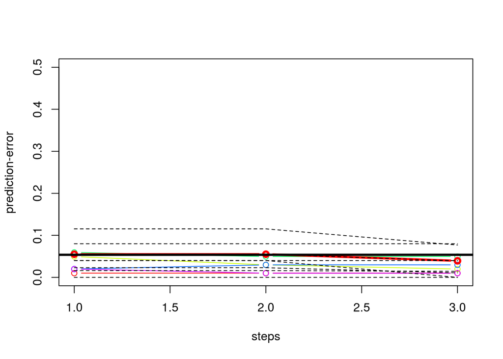

[1] “Prediction error at end is: 0.0550769230769231” [2] “Prediction error at end is: 0.0550769230769231” [3] “Prediction error at end is: 0.0393846153846154”

| k 1 | k 2 | k 3 | k 4 | k 5 |
| --- | --- | --- | --- | --- |
| slope_DTM_50m_avg_ws9_50m | TotalCurvature_10m | maxic_ws3_10m | longc_DTM_50m_avg_ws7_50m | longc_DTM_50m_avg_ws7_50m |
| FlowLineCurvature_10m | planc_DTM_50m_avg_ws11_50m | longc_ws19_hr_hr | profc_DTM_50m_avg_ws7_50m | TotalCurvature_10m |
| LongitudinalCurvature_10m | Longitudinal_Curvature_50m | dtm_hr_CONVEX_r10 | maxic_ws9_hr_hr | Total_Curvature_hr |

[1] “OBB error with all predictors of localterrain is 0.0476190476190476”

|  | DC | SD | MeanDecreaseAccuracy | MeanDecreaseGini |
| --- | --- | --- | --- | --- |
| slope_DTM_50m_avg_ws11_50m | 0.0073333 | 0.0032721 | 0.0034673 | 0.2770657 |
| TotalCurvature_10m | 0.0086667 | 0.0027785 | 0.0028803 | 0.1674916 |
| slope_ws29_hr_hr | 0.0011667 | 0.0029364 | 0.0027539 | 0.2273269 |
| maxic_ws29_hr_hr | 0.0003333 | 0.0022088 | 0.0020975 | 0.1334358 |
| slope_ws7_10m | 0.0035000 | 0.0019691 | 0.0019442 | 0.1233731 |
| slope_ws13_hr_hr | 0.0010000 | 0.0019187 | 0.0018572 | 0.1268917 |
| slope_ws23_hr_hr | 0.0026667 | 0.0018595 | 0.0018429 | 0.1193866 |
| slope_ws11_10m | 0.0031667 | 0.0017689 | 0.0017851 | 0.0972637 |
| slope_DTM_50m_avg_ws7_50m | 0.0019000 | 0.0016020 | 0.0016410 | 0.0997621 |
| Total_Curvature_50m | 0.0040000 | 0.0014305 | 0.0016392 | 0.1349896 |

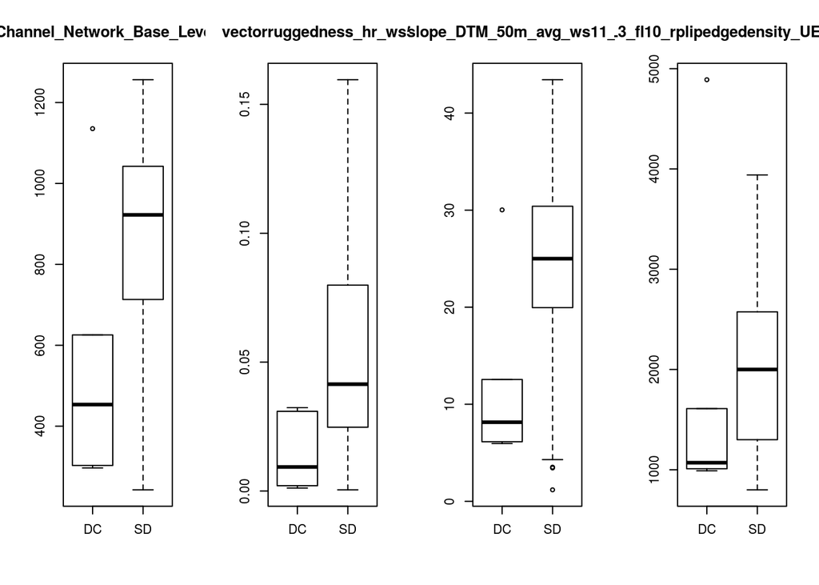

How does this compare to the differences between the units on the geological map?

[1] “OBB error with all predictors of allpreds is 0.0500782472613459”

|  | DC | SD | MeanDecreaseAccuracy | MeanDecreaseGini |
| --- | --- | --- | --- | --- |
| Modified_Catchment_Area_50m | 0.0224972 | 0.0156102 | 0.0193860 | 13.253495 |
| sagaTopographic_Wetness_Index_50m | 0.0282142 | 0.0063454 | 0.0183442 | 7.370957 |
| Normalized_Height_50m | 0.0205161 | 0.0095436 | 0.0155361 | 8.598800 |
| Topographic_Wetness_Index_50m | 0.0084307 | 0.0214861 | 0.0142904 | 50.242214 |
| VerticalDistancetoChannelNetwork_10m | 0.0225022 | 0.0015141 | 0.0129619 | 3.209735 |
| Vertical_Distance_to_Channel_Network_50m | 0.0196791 | 0.0022467 | 0.0117443 | 4.724559 |
| slope_DTM_50m_avg_ws11_50m | 0.0201312 | 0.0007103 | 0.0113611 | 4.015699 |
| Catchment_area_50m | 0.0031601 | 0.0210151 | 0.0112523 | 13.696052 |
| slope_ws11_10m | 0.0118465 | 0.0097041 | 0.0108650 | 33.135606 |
| TWI_10m | -0.0001871 | 0.0239627 | 0.0108222 | 4.493627 |

[1] “OBB error with all predictors of roughness is 0.0738569753810082”

|  | DC | SD | MeanDecreaseAccuracy | MeanDecreaseGini |
| --- | --- | --- | --- | --- |
| TRI_hr_ws48 | 0.0246249 | 0.0125638 | 0.0191323 | 26.73856 |
| TRI_hr_ws46 | 0.0233387 | 0.0112100 | 0.0178929 | 35.78445 |
| TRI_hr_ws50 | 0.0235806 | 0.0090780 | 0.0169077 | 29.03445 |
| TRI_hr_ws31 | 0.0189134 | 0.0137480 | 0.0165160 | 31.44656 |
| TRI_hr_ws47 | 0.0214282 | 0.0103748 | 0.0163530 | 19.93381 |
| TRI_hr_ws49 | 0.0208067 | 0.0101759 | 0.0159627 | 28.29766 |
| TRI_hr_ws22 | 0.0183550 | 0.0121169 | 0.0154881 | 33.22704 |
| TRI_hr_ws19 | 0.0177066 | 0.0120171 | 0.0151214 | 40.00226 |
| TRI_hr_ws20 | 0.0181218 | 0.0108226 | 0.0147673 | 32.05158 |
| TRI_hr_ws26 | 0.0155658 | 0.0131764 | 0.0144518 | 28.73608 |

[1] “OBB error with all predictors of localterrain is 0.0682527301092044”

|  | DC | SD | MeanDecreaseAccuracy | MeanDecreaseGini |
| --- | --- | --- | --- | --- |
| slope_ws15_10m | 0.0376978 | 0.0385434 | 0.0380372 | 67.61092 |
| slope_ws11_10m | 0.0323159 | 0.0337641 | 0.0329055 | 64.39656 |
| slope_DTM_50m_avg_ws5_50m | 0.0395669 | 0.0215718 | 0.0314006 | 56.91661 |
| Slope_50m | 0.0319654 | 0.0272680 | 0.0298073 | 69.39750 |
| slope_DTM_50m_avg_ws11_50m | 0.0474837 | 0.0051071 | 0.0281598 | 29.75916 |
| slope_DTM_50m_avg_ws3_50m | 0.0268514 | 0.0285982 | 0.0276471 | 47.41151 |
| slope_DTM_50m_avg_ws9_50m | 0.0389324 | 0.0113240 | 0.0264020 | 37.40231 |
| slope_ws29_hr_hr | 0.0259312 | 0.0218152 | 0.0240620 | 47.43321 |
| slope_ws7_10m | 0.0259028 | 0.0203619 | 0.0234437 | 47.41240 |
| slope_DTM_50m_avg_ws7_50m | 0.0332962 | 0.0098600 | 0.0226951 | 27.08995 |

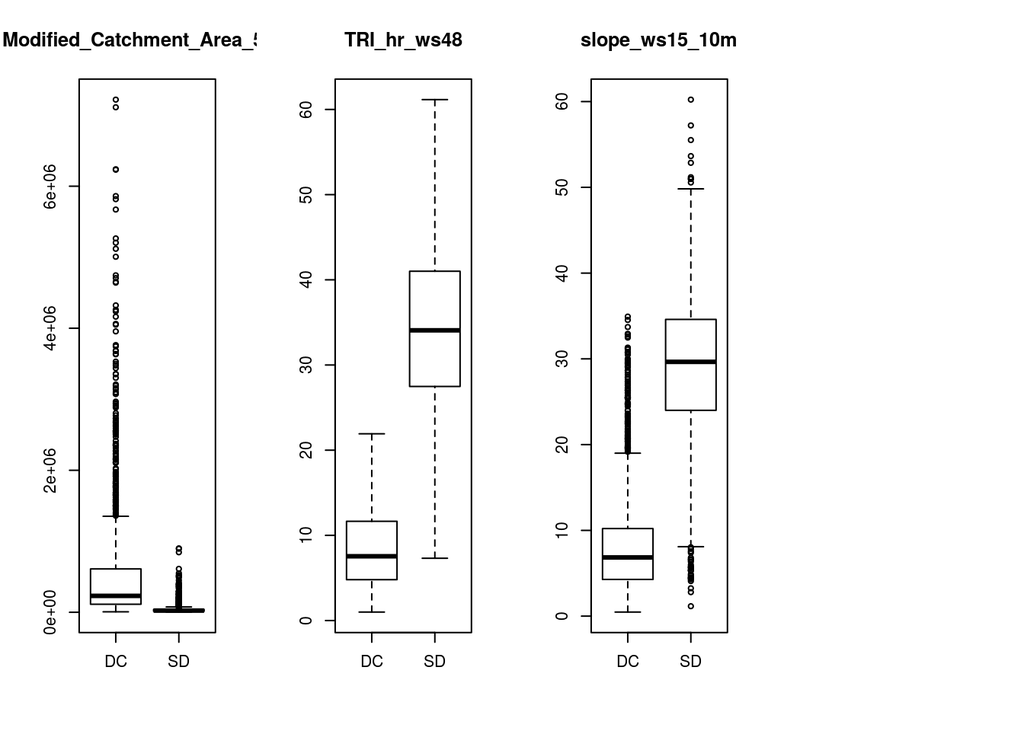

How about calcareous sedimentary rock

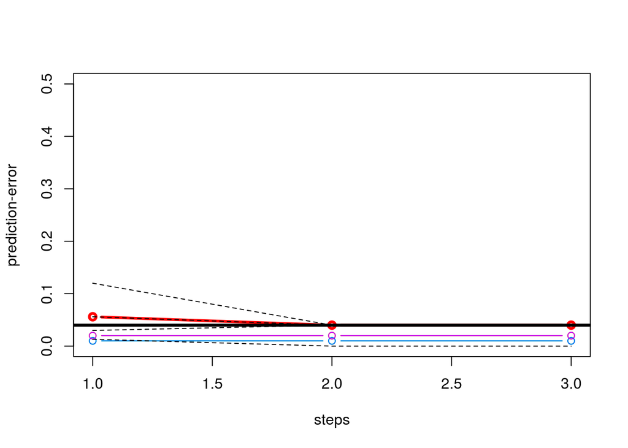

[1] “Prediction error at end is: 0.056” [2] “Prediction error at end is: 0.04” [3] “Prediction error at end is: 0.04”

| k 1 | k 2 | k 3 | k 4 | k 5 |
| --- | --- | --- | --- | --- |
| maxic_DTM_50m_avg_ws5_50m | terraintexture_hr_ws37_tp5 | geom_hr_L3_fl10_rplipmps_UE_hr_20cells_hr | geom_hr_L3_fl10_rplipmps_UE_hr_20cells_hr | maxic_DTM_50m_avg_ws5_50m |
| ChannelNetworkBaseLevel_10m | geom_hr_L3_fl10_rplipmps_UE_hr_20cells_hr | geom_hr_L3_fl10_rplippatchdensity_UE_hr_20cells_hr | geom_hr_L3_fl10_rplippatchdensity_UE_hr_20cells_hr | LS_Factor_50m |
| planc_ws7_10m | geom_hr_L3_fl1_rplipedgedensity_UE_hr_5cells_hr | geom_hr_L3_fl10_rplippatchnum_UE_hr_20cells_hr | geom_hr_L3_fl10_rplippatchnum_UE_hr_20cells_hr | TRI_hr_ws36 |

[1] “OBB error with all predictors of allpreds is 0.04”

|  | CSR | SD | MeanDecreaseAccuracy | MeanDecreaseGini |
| --- | --- | --- | --- | --- |
| Tangential_Curvature_50m | 0.0020000 | 0.0011995 | 0.0011982 | 0.0421870 |
| SlopeHeight_10m | 0.0060000 | 0.0009411 | 0.0010841 | 0.1145806 |
| Profile_Curvature_hr | -0.0010000 | 0.0009640 | 0.0008749 | 0.0248473 |
| vectorstrength_hr_ws61_hr | 0.0000000 | 0.0007224 | 0.0007108 | 0.0223343 |
| longc_ws3_hr_hr | -0.0006667 | 0.0007774 | 0.0006928 | 0.0171275 |
| TRI_hr_ws41 | 0.0020000 | 0.0006049 | 0.0006339 | 0.0368070 |
| longc_ws19_hr_hr | 0.0013333 | 0.0006431 | 0.0006223 | 0.0541698 |
| geom_hr_L3_fl10_rplipmps_UE_hr_20cells_hr | -0.0020000 | 0.0006694 | 0.0006104 | 0.0229225 |
| maxic_DTM_50m_avg_ws5_50m | 0.0016667 | 0.0005454 | 0.0006058 | 0.0192017 |
| GeneralCurvature_10m | 0.0000000 | 0.0006202 | 0.0006022 | 0.0422284 |

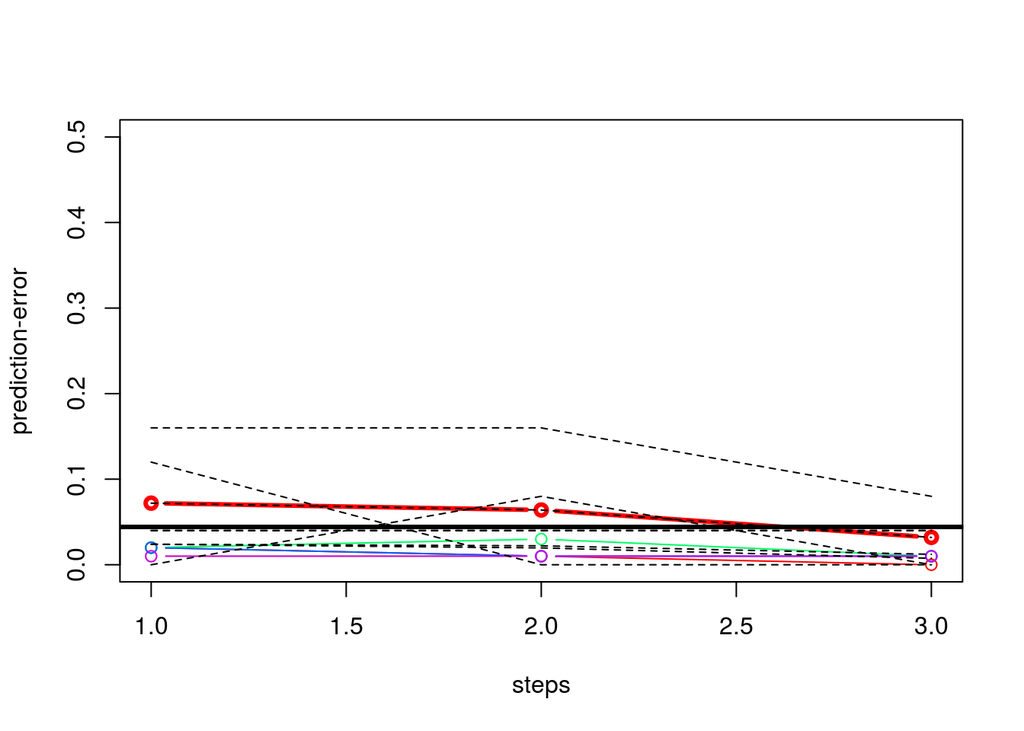

[1] “Prediction error at end is: 0.072” [2] “Prediction error at end is: 0.064” [3] “Prediction error at end is: 0.032”

| k 1 | k 2 | k 3 | k 4 | k 5 |
| --- | --- | --- | --- | --- |
| geom_hr_L3_fl10_rplippatchdensity_UE_hr_20cells_hr | geom_hr_L3_fl10_rplipmps_UE_hr_20cells_hr | TRI_hr_ws36 | geom_hr_L3_fl1_rplipmps_UE_hr_40cells_hr | geom_hr_L3_fl10_rplipmps_UE_hr_20cells_hr |
| TRI_hr_ws36 | geom_hr_L3_fl10_rplippatchdensity_UE_hr_20cells_hr | geom_hr_L3_fl10_rplipmps_UE_hr_20cells_hr | geom_hr_L3_fl1_rplippatchdensity_UE_hr_40cells_hr | geom_hr_L3_fl10_rplippatchdensity_UE_hr_20cells_hr |
| geom_hr_L3_fl10_rplipmps_UE_hr_20cells_hr | geom_hr_L3_fl10_rplippatchnum_UE_hr_20cells_hr | TRI_hr_ws42 | geom_hr_L50m_fl1_rplipdominance_UE_hr_40cells_hr | geom_hr_L3_fl10_rplippatchnum_UE_hr_20cells_hr |

[1] “OBB error with all predictors of roughness is 0.04”

|  | CSR | SD | MeanDecreaseAccuracy | MeanDecreaseGini |
| --- | --- | --- | --- | --- |
| TRI_hr_ws48 | -0.0003333 | 0.0021841 | 0.0021062 | 0.0544755 |
| geom_hr_L50m_fl1_rplipmps_UE_hr_60cells_hr | -0.0020000 | 0.0021624 | 0.0020424 | 0.0161917 |
| TRI_hr_ws41 | 0.0000000 | 0.0019909 | 0.0019324 | 0.0657593 |
| geom_hr_L50m_fl10_rplipshannon_UE_hr_40cells_hr | 0.0000000 | 0.0017922 | 0.0017254 | 0.0256301 |
| TRI_hr_ws47 | 0.0003333 | 0.0017076 | 0.0016561 | 0.0762459 |
| vectorruggedness_hr_ws7 | 0.0000000 | 0.0016870 | 0.0016459 | 0.0427924 |
| TRI_hr_ws45 | -0.0001667 | 0.0017190 | 0.0016388 | 0.0725709 |
| geom_hr_L50m_fl1_rplipsimpson_UE_hr_60cells_hr | 0.0000000 | 0.0016470 | 0.0016073 | 0.0333573 |
| TRI_hr_ws43 | -0.0020000 | 0.0016805 | 0.0015908 | 0.0781325 |
| TRI_hr_ws46 | 0.0006667 | 0.0014885 | 0.0014659 | 0.0410651 |

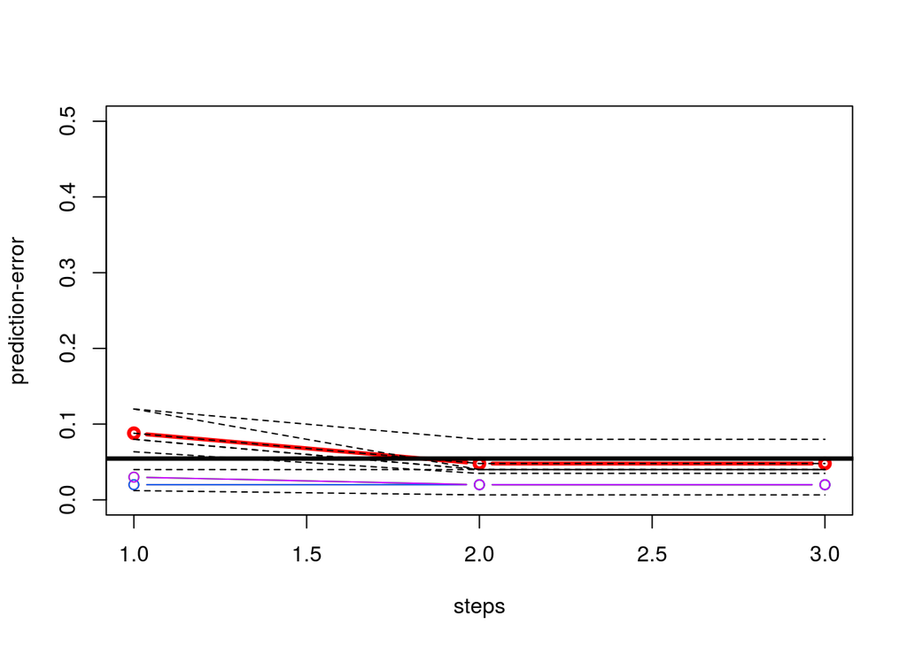

[1] “Prediction error at end is: 0.088” [2] “Prediction error at end is: 0.048” [3] “Prediction error at end is: 0.048”

| k 1 | k 2 | k 3 | k 4 | k 5 |
| --- | --- | --- | --- | --- |
| slope_DTM_50m_avg_ws9_50m | maxic_ws7_10m | minic_ws11_10m | maxic_DTM_50m_avg_ws5_50m | longc_ws23_hr_hr |
| slope_DTM_50m_avg_ws11_50m | slope_ws29_hr_hr | Tangential_Curvature_50m | profc_DTM_50m_avg_ws7_50m | longc_ws29_hr_hr |
| crosc_ws7_10m | Convergence_Index_hr | longc_ws23_hr_hr | slope_ws23_hr_hr | minic_ws11_10m |

[1] “OBB error with all predictors of localterrain is 0.04”

|  | CSR | SD | MeanDecreaseAccuracy | MeanDecreaseGini |
| --- | --- | --- | --- | --- |
| maxic_DTM_50m_avg_ws5_50m | 0.0010000 | 0.0011650 | 0.0011829 | 0.1110386 |
| profc_ws11_10m | -0.0010000 | 0.0008060 | 0.0007214 | 0.1760028 |
| maxic_DTM_50m_avg_ws3_50m | 0.0000000 | 0.0006826 | 0.0006633 | 0.0179907 |
| maxic_ws29_hr_hr | 0.0000000 | 0.0006751 | 0.0006579 | 0.0630343 |
| longc_ws19_hr_hr | 0.0000000 | 0.0006919 | 0.0006565 | 0.0651732 |
| profc_ws3_10m | 0.0000000 | 0.0006249 | 0.0006028 | 0.0490434 |
| profc_ws29_hr_hr | 0.0000000 | 0.0006165 | 0.0005981 | 0.3100854 |
| maxic_ws11_10m | 0.0000000 | 0.0005855 | 0.0005761 | 0.0533341 |
| minic_ws11_10m | -0.0006667 | 0.0005224 | 0.0005439 | 0.1387287 |
| longc_ws3_hr_hr | 0.0000000 | 0.0005433 | 0.0005227 | 0.0196182 |

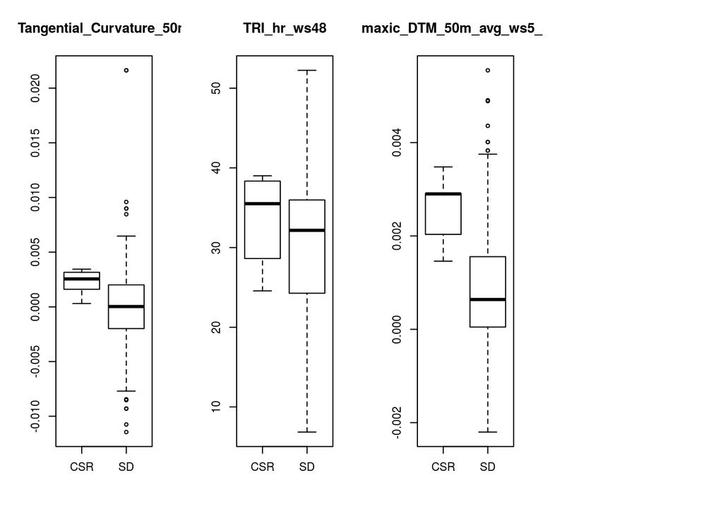

How does this compare to the differences between the units on the geological map?

[1] “OBB error with all predictors of allpreds is 0.145933014354067”

|  | CSR | SD | MeanDecreaseAccuracy | MeanDecreaseGini |
| --- | --- | --- | --- | --- |
| elev_ws11_10m | 0.0230415 | 0.0183250 | 0.0203653 | 26.907364 |
| elev_ws3_10m | 0.0202621 | 0.0184071 | 0.0191761 | 23.187736 |
| elev_ws15_10m | 0.0203740 | 0.0172799 | 0.0186249 | 23.313090 |
| elev_ws5_10m | 0.0163009 | 0.0181004 | 0.0172896 | 26.111278 |
| Channel_Network_Base_Level_hr | 0.0177885 | 0.0139621 | 0.0156835 | 18.924519 |
| Channel_Network_Base_Level_50m | 0.0168328 | 0.0124451 | 0.0143746 | 20.550767 |
| Standardized_Height_50m | 0.0079813 | 0.0193545 | 0.0142480 | 23.098659 |
| ChannelNetworkBaseLevel_10m | 0.0137238 | 0.0103074 | 0.0118325 | 14.838245 |
| Relative_Slope_Position_50m | 0.0057337 | 0.0054274 | 0.0055540 | 7.116451 |
| StandardizedHeight_10m | 0.0034508 | 0.0049520 | 0.0042627 | 9.281946 |

[1] “OBB error with all predictors of roughness is 0.22848948374761”

|  | CSR | SD | MeanDecreaseAccuracy | MeanDecreaseGini |
| --- | --- | --- | --- | --- |
| TRI_hr_ws38 | 0.0103031 | 0.0033000 | 0.0064179 | 12.166837 |
| TRI_hr_ws40 | 0.0085030 | 0.0044914 | 0.0062691 | 9.873255 |
| TRI_hr_ws43 | 0.0076757 | 0.0049501 | 0.0061648 | 8.550613 |
| vectorruggedness_hr_ws59 | 0.0023736 | 0.0088754 | 0.0059873 | 6.953269 |
| TRI_hr_ws50 | 0.0063934 | 0.0052636 | 0.0057420 | 6.166499 |
| TRI_hr_ws22 | 0.0088786 | 0.0031875 | 0.0057181 | 14.863639 |
| TRI_hr_ws35 | 0.0077978 | 0.0038002 | 0.0055828 | 9.331369 |
| TRI_hr_ws45 | 0.0056073 | 0.0055605 | 0.0055738 | 6.494785 |
| TRI_hr_ws39 | 0.0079697 | 0.0035856 | 0.0055171 | 9.335676 |
| TRI_hr_ws49 | 0.0054202 | 0.0054610 | 0.0054235 | 7.761946 |

[1] “OBB error with all predictors of localterrain is 0.199235547061634”

|  | CSR | SD | MeanDecreaseAccuracy | MeanDecreaseGini |
| --- | --- | --- | --- | --- |
| dtm_hr_CONVEX_r30 | 0.0126601 | 0.0114175 | 0.0119412 | 25.32077 |
| slope_ws23_hr_hr | 0.0063334 | 0.0111868 | 0.0089901 | 22.24377 |
| slope_ws29_hr_hr | 0.0083988 | 0.0091790 | 0.0088608 | 21.42386 |
| slope_ws7_10m | 0.0094565 | 0.0084004 | 0.0088224 | 19.86523 |
| slope_ws5_10m | 0.0070980 | 0.0100226 | 0.0086957 | 24.19353 |
| profc_DTM_50m_avg_ws11_50m | 0.0052234 | 0.0110329 | 0.0084612 | 13.07378 |
| slope_ws11_10m | 0.0090941 | 0.0071645 | 0.0080326 | 22.28999 |
| Slope_50m | 0.0063104 | 0.0087887 | 0.0077104 | 16.58102 |
| slope_ws15_10m | 0.0096942 | 0.0059743 | 0.0075964 | 16.12858 |
| slope_ws19_hr_hr | 0.0075188 | 0.0071324 | 0.0073053 | 18.67421 |

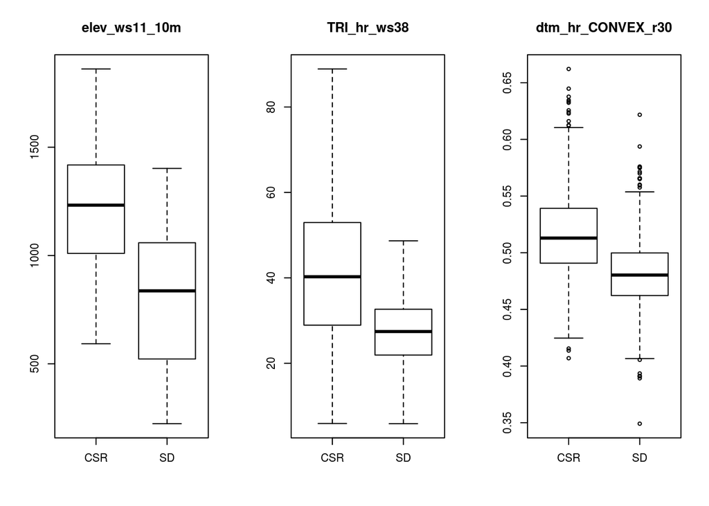

How about coarse blocky debris

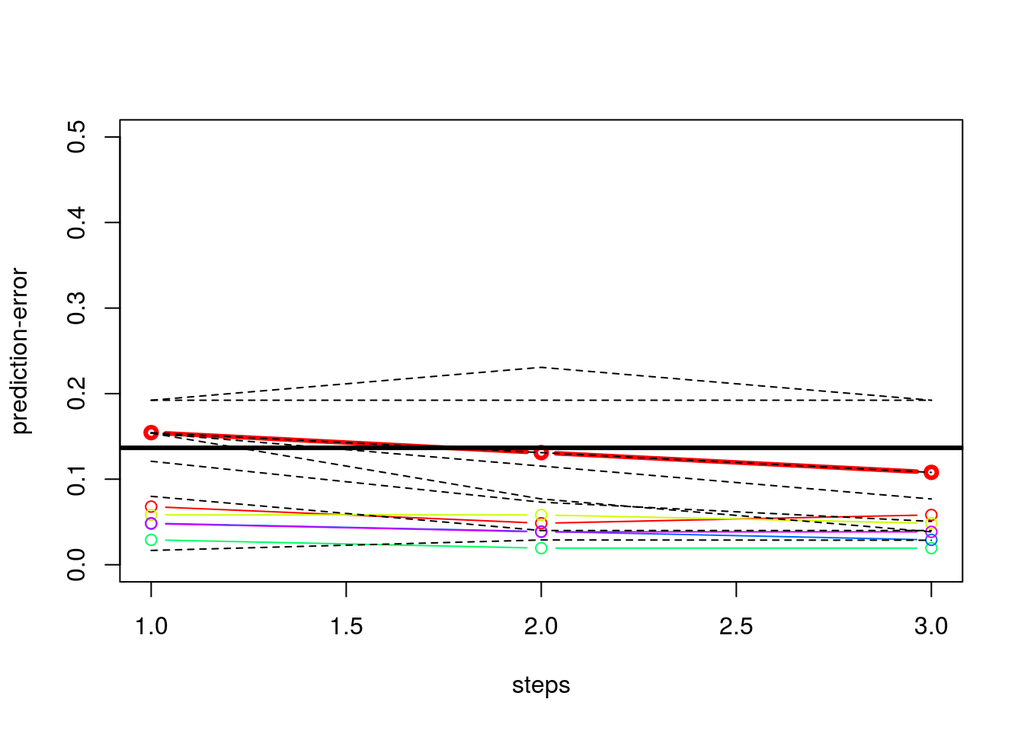

[1] “Prediction error at end is: 0.154461538461538” [2] “Prediction error at end is: 0.131076923076923” [3] “Prediction error at end is: 0.108”

| k 1 | k 2 | k 3 | k 4 | k 5 |
| --- | --- | --- | --- | --- |
| profc_ws15_10m | geom_hr_L3_fl1_rplipedgedensity_UE_hr_20cells_hr | geom_hr_L3_fl10_rplipshannon_UE_hr_60cells_hr | profc_ws11_hr_hr | vectorruggedness_hr_ws15 |
| geom_hr_L3_fl10_rplipmps_UE_hr_20cells_hr | geom_hr_L3_fl1_rplipshape_UE_hr_20cells_hr | geom_hr_L3_fl10_rplipsimpson_UE_hr_60cells_hr | terraintexture_hr_ws25_tp25 | profc_ws11_hr_hr |
| geom_hr_L50m_fl1_rplipedgedensity_UE_hr_60cells_hr | geom_hr_L3_fl1_rpliprichness_UE_hr_20cells_hr | geom_hr_L50m_fl10_rplipmps_UE_hr_40cells_hr | longc_ws11_hr_hr | profc_ws15_hr_hr |

[1] “OBB error with all predictors of allpreds is 0.0697674418604651”

|  | CBD | SD | MeanDecreaseAccuracy | MeanDecreaseGini |
| --- | --- | --- | --- | --- |
| profc_ws5_hr_hr | 0.0118000 | 0.0012123 | 0.0019093 | 0.2624357 |
| Profile_Curvature_hr | 0.0046000 | 0.0006867 | 0.0010398 | 0.2074744 |
| profc_ws7_hr_hr | 0.0028000 | 0.0008761 | 0.0009405 | 0.0537068 |
| maxic_ws23_hr_hr | 0.0083333 | 0.0005322 | 0.0008505 | 0.1568046 |
| longc_ws13_hr_hr | 0.0001667 | 0.0007925 | 0.0007939 | 0.0944361 |
| slope_ws3_hr_hr | 0.0010000 | 0.0007036 | 0.0007208 | 0.0597621 |
| profc_ws5_10m | 0.0020000 | 0.0007154 | 0.0007203 | 0.0738702 |
| minic_ws13_hr_hr | 0.0020000 | 0.0006796 | 0.0006942 | 0.0476332 |
| profc_ws3_hr_hr | 0.0030000 | 0.0005532 | 0.0006450 | 0.1642335 |
| profc_ws9_hr_hr | 0.0006667 | 0.0005861 | 0.0006403 | 0.0775598 |

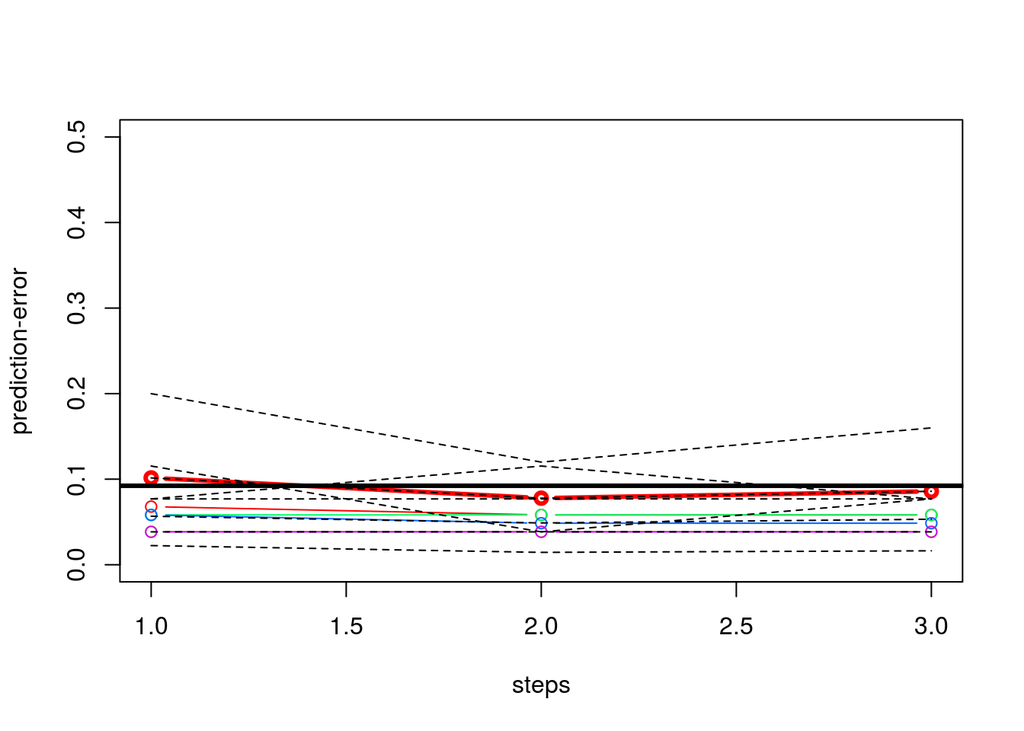

[1] “Prediction error at end is: 0.101538461538462” [2] “Prediction error at end is: 0.0778461538461538” [3] “Prediction error at end is: 0.0858461538461538”

| k 1 | k 2 | k 3 | k 4 | k 5 |
| --- | --- | --- | --- | --- |
| geom_hr_L3_fl10_rplipmps_UE_hr_20cells_hr | vectorruggedness_hr_ws15 | geom_hr_L3_fl1_rplipdominance_UE_hr_40cells_hr | geom_hr_L3_fl10_rplipmps_UE_hr_20cells_hr | geom_hr_L50m_fl1_rplipdominance_UE_hr_10cells_hr |
| geom_hr_L3_fl10_rplipshape_UE_hr_20cells_hr | terraintexture_hr_ws53_tp5 | geom_hr_L50m_fl10_rplipmps_UE_hr_20cells_hr | geom_hr_L3_fl10_rplipsimpson_UE_hr_20cells_hr | terraintexture_hr_ws25_tp25 |
| geom_hr_L3_fl10_rplippatchdensity_UE_hr_20cells_hr | terraintexture_hr_ws57_tp5 | vectorruggedness_hr_ws15 | geom_hr_L3_fl1_rplipmps_UE_hr_20cells_hr | geom_hr_L50m_fl1_rplipshannon_UE_hr_10cells_hr |

[1] “OBB error with all predictors of roughness is 0.0775193798449612”

|  | CBD | SD | MeanDecreaseAccuracy | MeanDecreaseGini |
| --- | --- | --- | --- | --- |
| TRI_hr_ws38 | 0.0000000 | 0.0019858 | 0.0018323 | 0.1264054 |
| TRI_hr_ws45 | 0.0029333 | 0.0014244 | 0.0015519 | 0.1380302 |
| TRI_hr_ws48 | 0.0023333 | 0.0014351 | 0.0015204 | 0.1397137 |
| TRI_hr_ws47 | 0.0043000 | 0.0013205 | 0.0015072 | 0.1253783 |
| TRI_hr_ws2 | 0.0015000 | 0.0015058 | 0.0014970 | 0.0661774 |
| TRI_hr_ws4 | -0.0026667 | 0.0015283 | 0.0013464 | 0.0389539 |
| TRI_hr_ws46 | 0.0003333 | 0.0013835 | 0.0012935 | 0.2046514 |
| TRI_hr_ws49 | 0.0005524 | 0.0012925 | 0.0012572 | 0.1660573 |
| geom_hr_L3_fl1_rplippatchdensity_UE_hr_60cells_hr | -0.0010667 | 0.0014002 | 0.0011731 | 0.0956410 |
| geom_hr_L3_fl10_rplipshannon_UE_hr_40cells_hr | 0.0000000 | 0.0012625 | 0.0011690 | 0.0843038 |

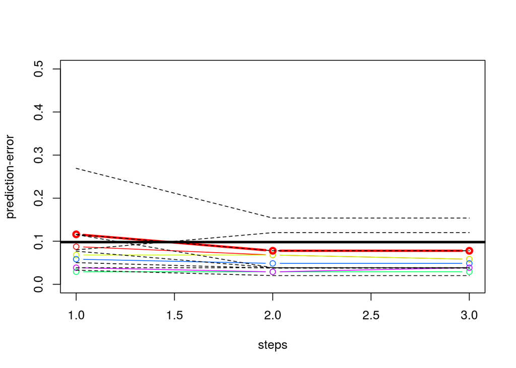

[1] “Prediction error at end is: 0.116”  
[2] “Prediction error at end is: 0.0778461538461538” [3] “Prediction error at end is: 0.0778461538461538”

| k 1 | k 2 | k 3 | k 4 | k 5 |
| --- | --- | --- | --- | --- |
| minic_DTM_50m_avg_ws5_50m | crosc_ws3_hr_hr | maxic_ws9_hr_hr | minic_ws19_hr_hr | longc_ws15_hr_hr |
| maxic_ws3_hr_hr | minic_ws19_hr_hr | crosc_ws11_hr_hr | crosc_ws19_hr_hr | maxic_ws5_hr_hr |
| longc_ws15_hr_hr | longc_DTM_50m_avg_ws5_50m | crosc_DTM_50m_avg_ws5_50m | longc_ws15_hr_hr | planc_ws19_hr_hr |

[1] “OBB error with all predictors of localterrain is 0.0697674418604651”

|  | CBD | SD | MeanDecreaseAccuracy | MeanDecreaseGini |
| --- | --- | --- | --- | --- |
| profc_ws5_hr_hr | 0.0175667 | 0.0019878 | 0.0030055 | 0.5163925 |
| profc_ws5_10m | 0.0013333 | 0.0028879 | 0.0028177 | 0.1788986 |
| longc_ws15_hr_hr | 0.0003333 | 0.0027464 | 0.0025646 | 0.1789942 |
| Longitudinal_Curvature_hr | -0.0000667 | 0.0025641 | 0.0024049 | 0.0880497 |
| profc_ws11_hr_hr | -0.0014333 | 0.0023002 | 0.0021807 | 0.0787268 |
| longc_ws19_hr_hr | 0.0025000 | 0.0019376 | 0.0019353 | 0.1414100 |
| longc_ws13_hr_hr | -0.0017333 | 0.0020570 | 0.0018022 | 0.1199993 |
| profc_ws13_hr_hr | -0.0005000 | 0.0016756 | 0.0015494 | 0.0665627 |
| minic_ws13_hr_hr | -0.0011667 | 0.0017002 | 0.0015101 | 0.0823822 |
| longc_ws5_10m | 0.0018333 | 0.0013908 | 0.0013984 | 0.1050664 |

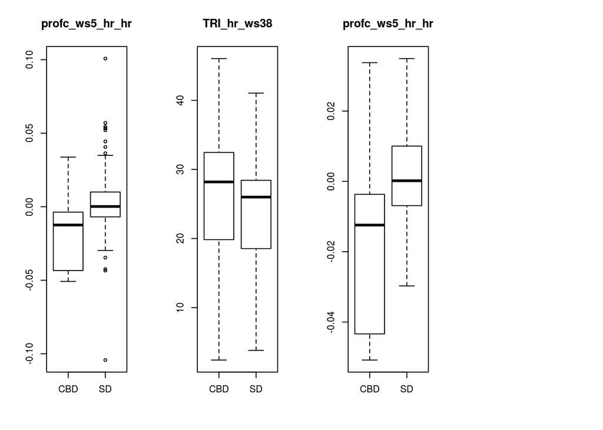

How does this compare to the differences between the units on the geological map?

[1] “OBB error with all predictors of allpreds is 0.138563049853372”

|  | CBD | SD | MeanDecreaseAccuracy | MeanDecreaseGini |
| --- | --- | --- | --- | --- |
| Texture_50m | 0.0109307 | 0.0042010 | 0.0051840 | 3.457074 |
| ValleyDepth_10m | 0.0122252 | 0.0037576 | 0.0050208 | 5.331767 |
| Channel_Network_Base_Level_50m | 0.0077110 | 0.0042053 | 0.0047341 | 3.717450 |
| Vertical_Distance_to_Channel_Network_50m | 0.0124111 | 0.0026304 | 0.0041208 | 5.532850 |
| elev_ws15_10m | 0.0049122 | 0.0032086 | 0.0034551 | 2.844811 |
| slope_DTM_50m_avg_ws7_50m | 0.0010864 | 0.0035487 | 0.0031861 | 1.713322 |
| elev_ws5_10m | 0.0044009 | 0.0028999 | 0.0031064 | 3.114196 |
| elev_ws3_10m | 0.0043080 | 0.0027690 | 0.0030103 | 3.317476 |
| RelativeSlopePosition_10m | 0.0084171 | 0.0018707 | 0.0028548 | 4.381616 |
| ChannelNetworkBaseLevel_10m | 0.0064782 | 0.0021064 | 0.0027782 | 2.888296 |

[1] “OBB error with all predictors of roughness is 0.151537335285505”

|  | CBD | SD | MeanDecreaseAccuracy | MeanDecreaseGini |
| --- | --- | --- | --- | --- |
| TRI_hr_ws50 | -0.0013633 | 0.0074566 | 0.0061134 | 2.191369 |
| geom_hr_L3_fl10_rplipedgedensity_UE_hr_60cells_hr | 0.0008595 | 0.0063715 | 0.0055338 | 2.943027 |
| geom_hr_L3_fl10_rplipshape_UE_hr_60cells_hr | -0.0009339 | 0.0065464 | 0.0054504 | 2.611745 |
| TRI_hr_ws48 | -0.0014703 | 0.0063155 | 0.0051590 | 1.949560 |
| geom_hr_L3_fl10_rplippatchnum_UE_hr_60cells_hr | -0.0017873 | 0.0056273 | 0.0045150 | 2.310973 |
| TRI_hr_ws49 | 0.0001248 | 0.0045837 | 0.0038858 | 2.125134 |
| TRI_hr_ws46 | -0.0027518 | 0.0050424 | 0.0038606 | 1.874035 |
| Texture_50m | 0.0183133 | 0.0011860 | 0.0037346 | 7.608765 |
| TRI_hr_ws43 | -0.0015792 | 0.0046815 | 0.0037330 | 1.656801 |
| geom_hr_L3_fl10_rplipmps_UE_hr_60cells_hr | -0.0022981 | 0.0046294 | 0.0035786 | 2.229427 |

[1] “OBB error with all predictors of localterrain is 0.148500365764448”

|  | CBD | SD | MeanDecreaseAccuracy | MeanDecreaseGini |
| --- | --- | --- | --- | --- |
| slope_DTM_50m_avg_ws11_50m | 0.0110068 | 0.0058491 | 0.0066236 | 8.635221 |
| slope_DTM_50m_avg_ws7_50m | 0.0023848 | 0.0064434 | 0.0058509 | 4.412871 |
| slope_DTM_50m_avg_ws5_50m | 0.0017186 | 0.0056238 | 0.0050226 | 3.365490 |
| dtm_hr_CONVEX_r30 | 0.0034610 | 0.0048974 | 0.0046875 | 6.278571 |
| longc_DTM_50m_avg_ws11_50m | -0.0007247 | 0.0051780 | 0.0042885 | 4.060265 |
| dtm_hr_CONVEX_r20 | 0.0004650 | 0.0042026 | 0.0036265 | 4.290168 |
| slope_DTM_50m_avg_ws9_50m | 0.0013946 | 0.0038608 | 0.0034734 | 4.373763 |
| slope_DTM_50m_avg_ws3_50m | -0.0003411 | 0.0035918 | 0.0029952 | 2.041881 |
| planc_DTM_50m_avg_ws11_50m | -0.0001294 | 0.0032362 | 0.0027302 | 2.772117 |
| profc_DTM_50m_avg_ws11_50m | -0.0018667 | 0.0034954 | 0.0026745 | 2.651291 |

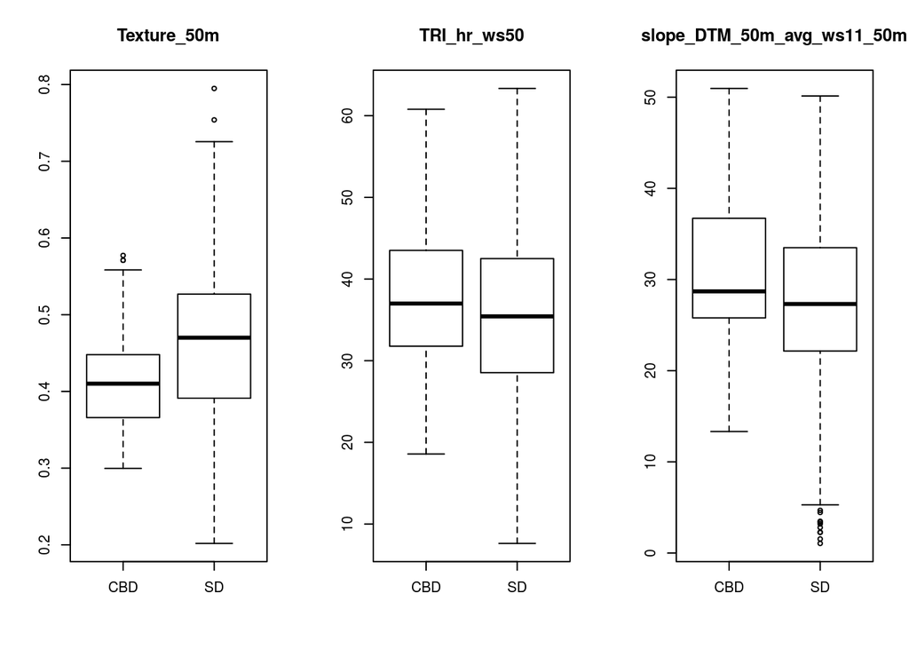

How about mixed deposits

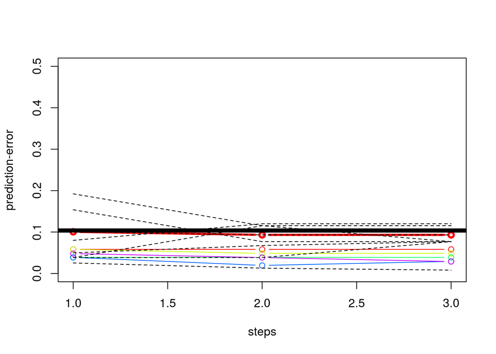

[1] “Prediction error at end is: 0.100615384615385” [2] “Prediction error at end is: 0.0932307692307692” [3] “Prediction error at end is: 0.0932307692307692”

| k 1 | k 2 | k 3 | k 4 | k 5 |
| --- | --- | --- | --- | --- |
| terraintexture_hr_ws17_tp25 | geom_hr_L50m_fl1_rplipdominance_UE_hr_5cells_hr | minic_ws9_hr_hr | minic_ws11_hr_hr | terraintexture_hr_ws37_tp5 |
| geom_hr_L3_fl10_rplippatchdensity_UE_hr_10cells_hr | terraintexture_hr_ws53_tp5 | minic_ws11_10m | geom_hr_L50m_fl1_rplipmps_UE_hr_60cells_hr | slope_DTM_50m_avg_ws9_50m |
| maxic_ws7_10m | Channel_Network_Base_Level_hr | Plan_Curvature_50m | longc_DTM_50m_avg_ws3_50m | geom_hr_L3_fl1_rplipsimpson_UE_hr_5cells_hr |

[1] “OBB error with all predictors of allpreds is 0.0697674418604651”

|  | MxD | SD | MeanDecreaseAccuracy | MeanDecreaseGini |
| --- | --- | --- | --- | --- |
| slope_DTM_50m_avg_ws9_50m | 0.0010000 | 0.0024305 | 0.0023751 | 0.0433983 |
| TRI_hr_ws27 | 0.0000000 | 0.0013697 | 0.0012780 | 0.0399193 |
| slope_DTM_50m_avg_ws11_50m | 0.0005000 | 0.0012422 | 0.0012317 | 0.0743309 |
| geom_hr_L3_fl1_rplipdominance_UE_hr_40cells_hr | 0.0005000 | 0.0012395 | 0.0012081 | 0.0596830 |
| slope_ws11_10m | 0.0000000 | 0.0012299 | 0.0011538 | 0.0396982 |
| TRI_hr_ws30 | 0.0000000 | 0.0012360 | 0.0011406 | 0.0368727 |
| TRI_hr_ws14 | -0.0014000 | 0.0013063 | 0.0011226 | 0.0571811 |
| TRI_hr_ws50 | 0.0015000 | 0.0011185 | 0.0010822 | 0.0386482 |
| TRI_hr_ws28 | 0.0006667 | 0.0009863 | 0.0009745 | 0.0322192 |
| TRI_hr_ws47 | -0.0005000 | 0.0010195 | 0.0009281 | 0.0177681 |

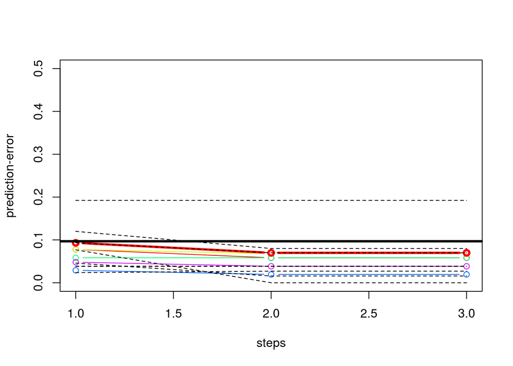

[1] “Prediction error at end is: 0.0932307692307692” [2] “Prediction error at end is: 0.0698461538461538” [3] “Prediction error at end is: 0.0698461538461538”

| k 1 | k 2 | k 3 | k 4 | k 5 |
| --- | --- | --- | --- | --- |
| geom_hr_L3_fl10_rplipedgedensity_UE_hr_10cells_hr | geom_hr_L50m_fl10_rplipsimpson_UE_hr_60cells_hr | geom_hr_L50m_fl1_rplipdominance_UE_hr_5cells_hr | geom_hr_L3_fl10_rplipmps_UE_hr_60cells_hr | terraintexture_hr_ws33_tp25 |
| terraintexture_hr_ws45_tp25 | TRI_hr_ws14 | geom_hr_L50m_fl1_rplipsimpson_UE_hr_5cells_hr | geom_hr_L50m_fl1_rpliprichness_UE_hr_20cells_hr | geom_hr_L50m_fl1_rplipdominance_UE_hr_5cells_hr |
| geom_hr_L50m_fl1_rplipmps_UE_hr_10cells_hr | geom_hr_L50m_fl10_rplipdominance_UE_hr_20cells_hr | geom_hr_L3_fl1_rplipmps_UE_hr_10cells_hr | geom_hr_L3_fl10_rplipsimpson_UE_hr_60cells_hr | terraintexture_hr_ws41_tp25 |

[1] “OBB error with all predictors of roughness is 0.0775193798449612”

|  | MxD | SD | MeanDecreaseAccuracy | MeanDecreaseGini |
| --- | --- | --- | --- | --- |
| TRI_hr_ws24 | -0.0025000 | 0.0034387 | 0.0030423 | 0.1209281 |
| TRI_hr_ws25 | -0.0048000 | 0.0033860 | 0.0028773 | 0.0922860 |
| TRI_hr_ws22 | -0.0029000 | 0.0031807 | 0.0028124 | 0.0662844 |
| TRI_hr_ws28 | -0.0009000 | 0.0028138 | 0.0026446 | 0.0992115 |
| TRI_hr_ws29 | -0.0018333 | 0.0028291 | 0.0025412 | 0.0621283 |
| TRI_hr_ws34 | -0.0001667 | 0.0025018 | 0.0023397 | 0.0538357 |
| TRI_hr_ws21 | 0.0010667 | 0.0023387 | 0.0022177 | 0.0673057 |
| TRI_hr_ws35 | -0.0023333 | 0.0025404 | 0.0021993 | 0.0639104 |
| TRI_hr_ws23 | -0.0037000 | 0.0024963 | 0.0021169 | 0.0646980 |
| TRI_hr_ws19 | -0.0065000 | 0.0025087 | 0.0020430 | 0.0593696 |

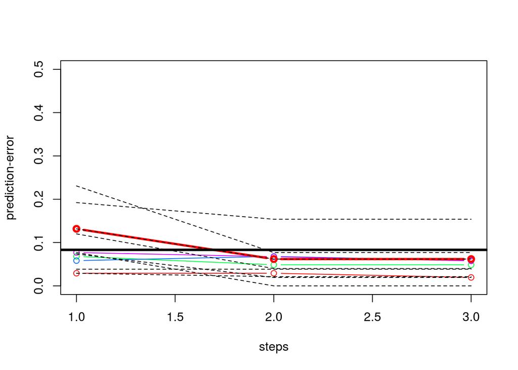

[1] “Prediction error at end is: 0.131692307692308” [2] “Prediction error at end is: 0.0618461538461538” [3] “Prediction error at end is: 0.0618461538461538”

| k 1 | k 2 | k 3 | k 4 | k 5 |
| --- | --- | --- | --- | --- |
| planc_ws19_hr_hr | maxic_ws15_10m | crosc_ws5_10m | slope_DTM_50m_avg_ws9_50m | Tangential_Curvature_50m |
| crosc_ws3_10m | slope_DTM_50m_avg_ws9_50m | slope_DTM_50m_avg_ws9_50m | crosc_ws5_10m | Plan_Curvature_50m |
| MaximalCurvature_10m | planc_ws23_hr_hr | crosc_ws19_hr_hr | slope_ws15_hr_hr | profc_DTM_50m_avg_ws11_50m |

[1] “OBB error with all predictors of localterrain is 0.0697674418604651”

|  | MxD | SD | MeanDecreaseAccuracy | MeanDecreaseGini |
| --- | --- | --- | --- | --- |
| slope_DTM_50m_avg_ws11_50m | 0.0059667 | 0.0048609 | 0.0048316 | 0.2674343 |
| slope_DTM_50m_avg_ws9_50m | 0.0075000 | 0.0030494 | 0.0033577 | 0.2628440 |
| profc_ws15_hr_hr | 0.0051667 | 0.0027717 | 0.0029235 | 0.2165335 |
| slope_ws13_hr_hr | 0.0010000 | 0.0023048 | 0.0021696 | 0.1710073 |
| slope_ws23_hr_hr | -0.0028333 | 0.0023276 | 0.0020142 | 0.0918236 |
| longc_ws23_hr_hr | 0.0002667 | 0.0018917 | 0.0017304 | 0.2216156 |
| slope_ws19_hr_hr | -0.0005000 | 0.0018243 | 0.0016461 | 0.0857492 |
| slope_DTM_50m_avg_ws5_50m | -0.0010000 | 0.0017598 | 0.0015955 | 0.1090289 |
| profc_DTM_50m_avg_ws3_50m | -0.0007810 | 0.0017082 | 0.0015828 | 0.1837868 |
| Total_Curvature_50m | -0.0017333 | 0.0017301 | 0.0015680 | 0.1096181 |

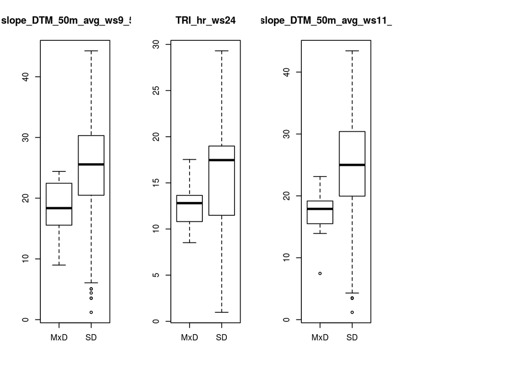

How does this compare to the differences between the units on the geological map?

[1] “OBB error with all predictors of allpreds is 0.0476529160739687”

|  | MxD | SD | MeanDecreaseAccuracy | MeanDecreaseGini |
| --- | --- | --- | --- | --- |
| slope_DTM_50m_avg_ws9_50m | 0.0469255 | 0.0092686 | 0.0159029 | 10.519662 |
| slope_DTM_50m_avg_ws11_50m | 0.0490008 | 0.0077645 | 0.0150166 | 10.076101 |
| slope_DTM_50m_avg_ws7_50m | 0.0276698 | 0.0109384 | 0.0138464 | 9.313255 |
| TRI_hr_ws50 | 0.0132145 | 0.0107266 | 0.0111656 | 8.664277 |
| slope_DTM_50m_avg_ws5_50m | 0.0199189 | 0.0091864 | 0.0111005 | 7.464020 |
| TRI_hr_ws46 | 0.0177449 | 0.0087445 | 0.0103109 | 7.408159 |
| Vertical_Distance_to_Channel_Network_50m | 0.0460530 | 0.0024372 | 0.0101005 | 6.914892 |
| TRI_hr_ws45 | 0.0183874 | 0.0083472 | 0.0100314 | 8.480481 |
| TRI_hr_ws47 | 0.0193930 | 0.0080422 | 0.0099839 | 7.428226 |
| TRI_hr_ws48 | 0.0098636 | 0.0087632 | 0.0089542 | 5.837371 |

[1] “OBB error with all predictors of roughness is 0.0802556818181818”

|  | MxD | SD | MeanDecreaseAccuracy | MeanDecreaseGini |
| --- | --- | --- | --- | --- |
| TRI_hr_ws48 | 0.0262725 | 0.0226514 | 0.0233223 | 12.019457 |
| TRI_hr_ws46 | 0.0231898 | 0.0230403 | 0.0229977 | 10.904856 |
| TRI_hr_ws50 | 0.0259038 | 0.0222069 | 0.0227443 | 8.482984 |
| TRI_hr_ws49 | 0.0288464 | 0.0204100 | 0.0218733 | 11.150300 |
| TRI_hr_ws47 | 0.0216432 | 0.0188417 | 0.0192843 | 8.645187 |
| TRI_hr_ws44 | 0.0276912 | 0.0173078 | 0.0190632 | 11.506364 |
| TRI_hr_ws45 | 0.0286386 | 0.0149063 | 0.0172917 | 7.393489 |
| TRI_hr_ws43 | 0.0208670 | 0.0160117 | 0.0168652 | 8.826132 |
| TRI_hr_ws42 | 0.0221204 | 0.0134202 | 0.0149069 | 7.951431 |
| TRI_hr_ws41 | 0.0186071 | 0.0140334 | 0.0147644 | 10.649193 |

[1] “OBB error with all predictors of localterrain is 0.07097232079489”

|  | MxD | SD | MeanDecreaseAccuracy | MeanDecreaseGini |
| --- | --- | --- | --- | --- |
| slope_DTM_50m_avg_ws9_50m | 0.0813604 | 0.0239745 | 0.0338025 | 27.002987 |
| slope_DTM_50m_avg_ws7_50m | 0.0657386 | 0.0202520 | 0.0280933 | 25.250486 |
| slope_DTM_50m_avg_ws11_50m | 0.0808853 | 0.0115013 | 0.0235902 | 20.205960 |
| slope_DTM_50m_avg_ws5_50m | 0.0396523 | 0.0153755 | 0.0196285 | 17.003289 |
| slope_ws15_10m | 0.0286206 | 0.0095622 | 0.0128422 | 12.449226 |
| slope_DTM_50m_avg_ws3_50m | 0.0271411 | 0.0083445 | 0.0116383 | 14.525465 |
| Slope_50m | 0.0166590 | 0.0088129 | 0.0102089 | 11.056596 |
| slope_ws11_10m | 0.0185839 | 0.0083887 | 0.0101624 | 10.089521 |
| slope_ws19_hr_hr | 0.0131268 | 0.0072605 | 0.0082875 | 7.495529 |
| slope_ws29_hr_hr | 0.0156998 | 0.0042884 | 0.0062963 | 5.663945 |

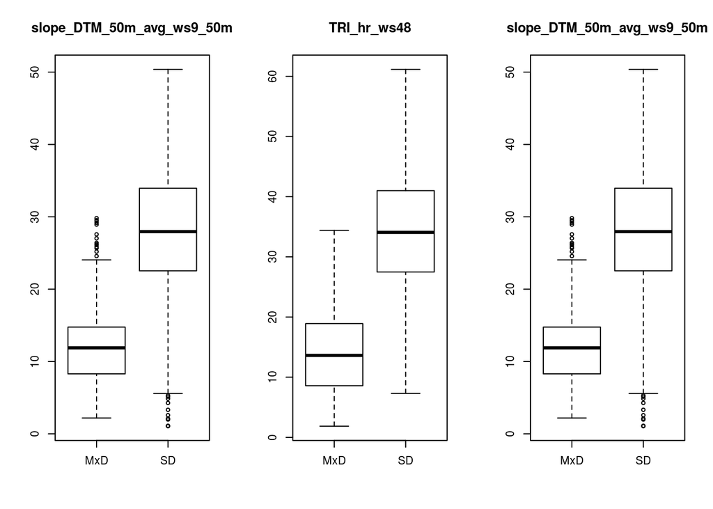

How about intermediate sedimentary rock

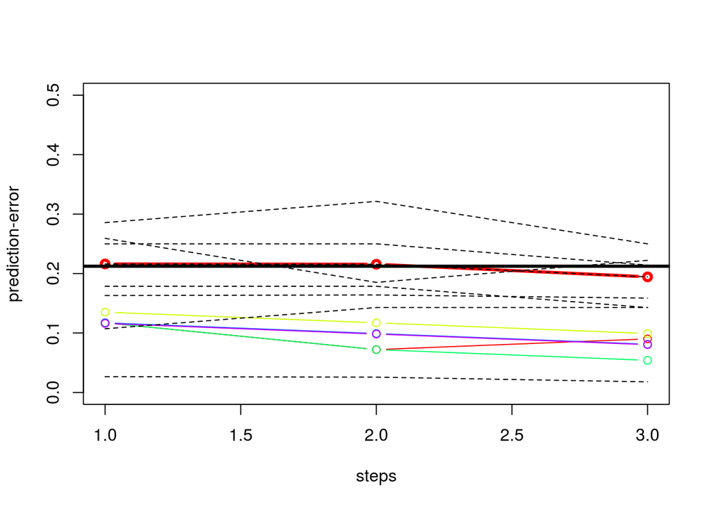

[1] “Prediction error at end is: 0.216137566137566” [2] “Prediction error at end is: 0.215608465608466” [3] “Prediction error at end is: 0.194444444444444”

| k 1 | k 2 | k 3 | k 4 | k 5 |
| --- | --- | --- | --- | --- |
| longc_DTM_50m_avg_ws11_50m | geom_hr_L50m_fl10_rplipshannon_UE_hr_5cells_hr | elev_ws3_10m | terraintexture_hr_ws41_tp5 | Relative_Slope_Position_50m |
| geom_hr_L50m_fl1_rplipedgedensity_UE_hr_40cells_hr | Minimal_Curvature_50m | profc_DTM_50m_avg_ws11_50m | TRI_hr_ws14 | geom_hr_L3_fl1_rplipshape_UE_hr_10cells_hr |
| geom_hr_L50m_fl1_rplipshape_UE_hr_40cells_hr | geom_hr_L50m_fl10_rpliprichness_UE_hr_20cells_hr | slope_DTM_50m_avg_ws9_50m | vectorstrength_hr_ws27_hr | planc_DTM_50m_avg_ws11_50m |

[1] “OBB error with all predictors of allpreds is 0.129496402877698”

|  | ISR | SD | MeanDecreaseAccuracy | MeanDecreaseGini |
| --- | --- | --- | --- | --- |
| Catchment_area_50m | 0.0053079 | 0.0022164 | 0.0024876 | 0.1741104 |
| Vertical_Distance_to_Channel_Network_50m | 0.0034381 | 0.0017899 | 0.0019890 | 0.1819942 |
| Modified_Catchment_Area_50m | 0.0015690 | 0.0018119 | 0.0017679 | 0.1520302 |
| slope_DTM_50m_avg_ws9_50m | 0.0007333 | 0.0018046 | 0.0017022 | 0.1818113 |
| planc_DTM_50m_avg_ws9_50m | 0.0062240 | 0.0008778 | 0.0016472 | 0.3886093 |
| crosc_DTM_50m_avg_ws11_50m | 0.0032984 | 0.0012328 | 0.0015004 | 0.2981605 |
| planc_DTM_50m_avg_ws11_50m | 0.0045683 | 0.0009905 | 0.0014632 | 0.4476271 |
| Minimal_Curvature_50m | 0.0027611 | 0.0013227 | 0.0014511 | 0.2723963 |
| terraintexture_hr_ws37_t1 | 0.0024722 | 0.0011479 | 0.0013139 | 0.1621693 |
| longc_ws11_10m | 0.0030595 | 0.0011228 | 0.0013126 | 0.2839433 |

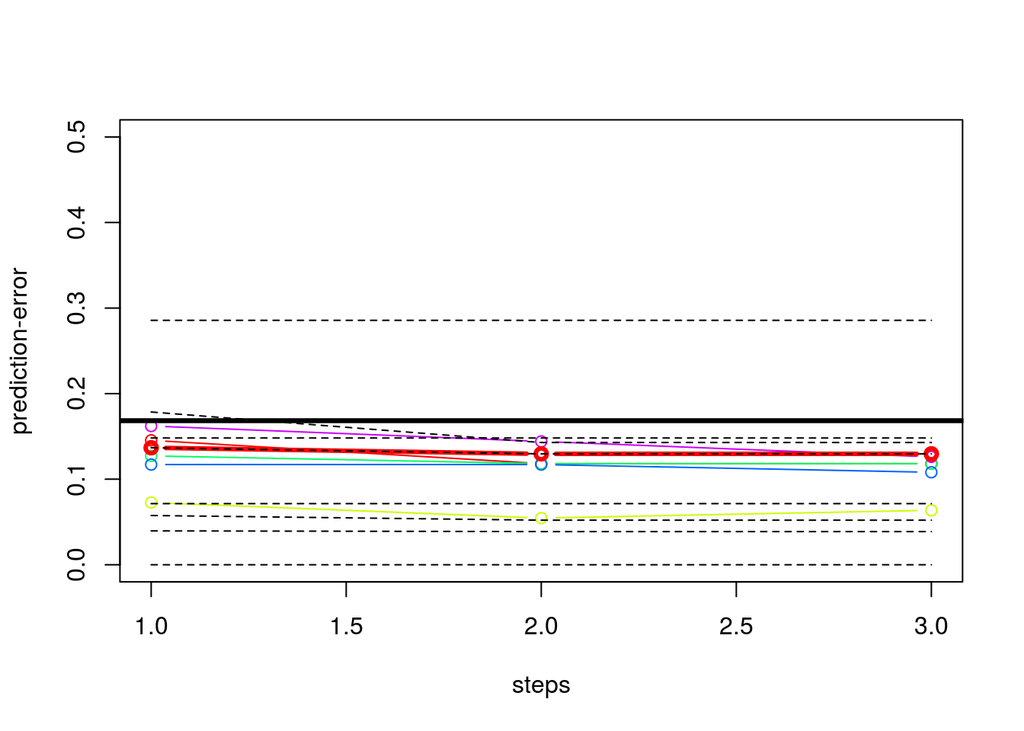

[1] “Prediction error at end is: 0.136772486772487” [2] “Prediction error at end is: 0.12962962962963” [3] “Prediction error at end is: 0.12962962962963”

| k 1 | k 2 | k 3 | k 4 | k 5 |
| --- | --- | --- | --- | --- |
| geom_hr_L3_fl10_rplipmps_UE_hr_5cells_hr | Texture_50m | geom_hr_L3_fl10_rplipdominance_UE_hr_5cells_hr | geom_hr_L3_fl10_rplipedgedensity_UE_hr_10cells_hr | geom_hr_L3_fl10_rplipmps_UE_hr_5cells_hr |
| geom_hr_L3_fl1_rplipmps_UE_hr_40cells_hr | fischerk_ws21_hr | geom_hr_L50m_fl10_rplippatchdensity_UE_hr_40cells_hr | geom_hr_L3_fl10_rplipshape_UE_hr_10cells_hr | vectorruggedness_hr_ws11 |
| geom_hr_L3_fl10_rpliprichness_UE_hr_20cells_hr | geom_hr_L50m_fl1_rplipsimpson_UE_hr_60cells_hr | geom_hr_L50m_fl1_rpliprichness_UE_hr_40cells_hr | vectorstrength_hr_ws49_hr | vectorstrength_hr_ws23_hr |

[1] “OBB error with all predictors of roughness is 0.136690647482014”

|  | ISR | SD | MeanDecreaseAccuracy | MeanDecreaseGini |
| --- | --- | --- | --- | --- |
| Texture_50m | 0.0101071 | 0.0036185 | 0.0044227 | 0.5439011 |
| terraintexture_hr_ws57_tp25 | 0.0007365 | 0.0038967 | 0.0033960 | 0.2934614 |
| vectorruggedness_hr_ws13 | -0.0019659 | 0.0029488 | 0.0023038 | 0.1842437 |
| geom_hr_L3_fl1_rplipsimpson_UE_hr_60cells_hr | -0.0003889 | 0.0025550 | 0.0021696 | 0.1754836 |
| vectorruggedness_hr_ws17 | 0.0014310 | 0.0022746 | 0.0021209 | 0.1156141 |
| vectorstrength_hr_ws31_hr | -0.0000635 | 0.0022706 | 0.0019664 | 0.0776920 |
| vectorruggedness_hr_ws15 | 0.0004032 | 0.0022190 | 0.0019415 | 0.1970947 |
| geom_hr_L3_fl1_rplipshape_UE_hr_40cells_hr | 0.0005714 | 0.0021213 | 0.0019177 | 0.0974749 |
| fischerk_ws37_hr | 0.0010079 | 0.0017221 | 0.0016337 | 0.1190497 |
| vectorstrength_hr_ws9_hr | -0.0000587 | 0.0017914 | 0.0016078 | 0.1538526 |

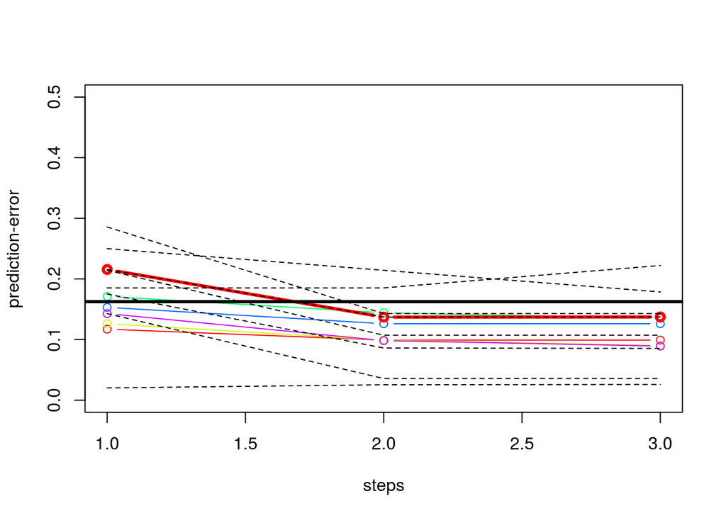

[1] “Prediction error at end is: 0.215608465608466” [2] “Prediction error at end is: 0.137037037037037” [3] “Prediction error at end is: 0.137301587301587”

| k 1 | k 2 | k 3 | k 4 | k 5 |
| --- | --- | --- | --- | --- |
| planc_DTM_50m_avg_ws9_50m | maxic_ws11_10m | crosc_DTM_50m_avg_ws3_50m | planc_DTM_50m_avg_ws9_50m | longc_DTM_50m_avg_ws11_50m |
| planc_ws13_hr_hr | LongitudinalCurvature_10m | slope_DTM_50m_avg_ws9_50m | profc_ws15_10m | profc_DTM_50m_avg_ws5_50m |
| planc_DTM_50m_avg_ws3_50m | profc_ws23_hr_hr | dtm_hr_CONVEX_r5 | profc_DTM_50m_avg_ws5_50m | minic_ws5_10m |

[1] “OBB error with all predictors of localterrain is 0.143884892086331”

|  | ISR | SD | MeanDecreaseAccuracy | MeanDecreaseGini |
| --- | --- | --- | --- | --- |
| planc_DTM_50m_avg_ws9_50m | 0.0105358 | 0.0024335 | 0.0035975 | 0.9553007 |
| slope_DTM_50m_avg_ws11_50m | 0.0047000 | 0.0022121 | 0.0025523 | 0.2724601 |
| slope_DTM_50m_avg_ws9_50m | 0.0037618 | 0.0023863 | 0.0025067 | 0.2545075 |
| Minimal_Curvature_50m | 0.0058741 | 0.0019365 | 0.0024813 | 0.4698774 |
| planc_DTM_50m_avg_ws11_50m | 0.0057159 | 0.0017075 | 0.0023612 | 0.9284720 |
| crosc_ws7_10m | 0.0034698 | 0.0020019 | 0.0022191 | 0.2314198 |
| slope_DTM_50m_avg_ws7_50m | 0.0019048 | 0.0017816 | 0.0017571 | 0.2302522 |
| minic_DTM_50m_avg_ws11_50m | 0.0059691 | 0.0010861 | 0.0016677 | 0.5237008 |
| minic_DTM_50m_avg_ws9_50m | 0.0026284 | 0.0014571 | 0.0015531 | 0.3223027 |
| longc_DTM_50m_avg_ws11_50m | 0.0026001 | 0.0013646 | 0.0015073 | 0.3098472 |

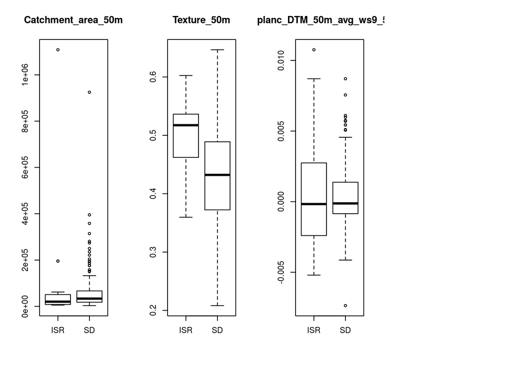

How does this compare to the differences between the units on the geological map?

[1] “OBB error with all predictors of allpreds is 0.0169923534409516”

|  | ISR | SD | MeanDecreaseAccuracy | MeanDecreaseGini |
| --- | --- | --- | --- | --- |
| TRI_hr_ws19 | -0.0013889 | 0.0010896 | 0.0010504 | 0.0716483 |
| TRI_hr_ws3 | 0.0004000 | 0.0009798 | 0.0009719 | 0.1111512 |
| slope_ws7_10m | -0.0014675 | 0.0009901 | 0.0009580 | 0.0800600 |
| TRI_hr_ws12 | -0.0020556 | 0.0009294 | 0.0008825 | 0.0546496 |
| crosc_ws11_hr_hr | -0.0003143 | 0.0008541 | 0.0008361 | 0.0693893 |
| TRI_hr_ws4 | 0.0008190 | 0.0007232 | 0.0007161 | 0.0463057 |
| slope_ws19_hr_hr | -0.0012024 | 0.0007071 | 0.0006840 | 0.0780346 |
| TRI_hr_ws21 | -0.0008333 | 0.0006889 | 0.0006705 | 0.0492754 |
| MRRTF_hr | -0.0006667 | 0.0006389 | 0.0006207 | 0.0602218 |
| terraintexture_hr_ws45_tp5 | -0.0014167 | 0.0006420 | 0.0006183 | 0.0981164 |

[1] “OBB error with all predictors of roughness is 0.0169635284139101”

|  | ISR | SD | MeanDecreaseAccuracy | MeanDecreaseGini |
| --- | --- | --- | --- | --- |
| TRI_hr_ws31 | -0.0036968 | 0.0034237 | 0.0033312 | 0.1127021 |
| TRI_hr_ws42 | -0.0035738 | 0.0033571 | 0.0032583 | 0.1278327 |
| TRI_hr_ws30 | -0.0044000 | 0.0033389 | 0.0032399 | 0.1773973 |
| TRI_hr_ws26 | -0.0024127 | 0.0030505 | 0.0029840 | 0.1114962 |
| TRI_hr_ws33 | -0.0034841 | 0.0030799 | 0.0029811 | 0.1448271 |
| TRI_hr_ws25 | -0.0047294 | 0.0029247 | 0.0028027 | 0.1921052 |
| geom_hr_L50m_fl1_rplipsimpson_UE_hr_60cells_hr | -0.0016959 | 0.0027742 | 0.0027031 | 0.2152880 |
| TRI_hr_ws36 | -0.0011667 | 0.0026992 | 0.0026485 | 0.0862871 |
| TRI_hr_ws28 | -0.0017667 | 0.0025180 | 0.0024504 | 0.1501931 |
| TRI_hr_ws46 | -0.0023571 | 0.0024923 | 0.0024318 | 0.1219054 |

[1] “OBB error with all predictors of localterrain is 0.0169491525423729”

|  | ISR | SD | MeanDecreaseAccuracy | MeanDecreaseGini |
| --- | --- | --- | --- | --- |
| crosc_ws15_hr_hr | -0.0003214 | 0.0025409 | 0.0024982 | 0.2509208 |
| crosc_ws13_hr_hr | -0.0029357 | 0.0019915 | 0.0019331 | 0.2405343 |
| crosc_ws11_hr_hr | 0.0016968 | 0.0018875 | 0.0018778 | 0.2811568 |
| slope_ws5_10m | -0.0022167 | 0.0015076 | 0.0014557 | 0.2390525 |
| crosc_ws23_hr_hr | -0.0005222 | 0.0014721 | 0.0014330 | 0.1304068 |
| maxic_ws3_10m | -0.0013374 | 0.0014506 | 0.0014135 | 0.3076355 |
| maxic_ws9_hr_hr | -0.0018238 | 0.0013536 | 0.0012963 | 0.2324426 |
| minic_ws23_hr_hr | -0.0014985 | 0.0013365 | 0.0012886 | 0.2116482 |
| slope_ws7_10m | -0.0017786 | 0.0013189 | 0.0012780 | 0.2452139 |
| crosc_DTM_50m_avg_ws7_50m | -0.0013135 | 0.0012934 | 0.0012531 | 0.2889163 |

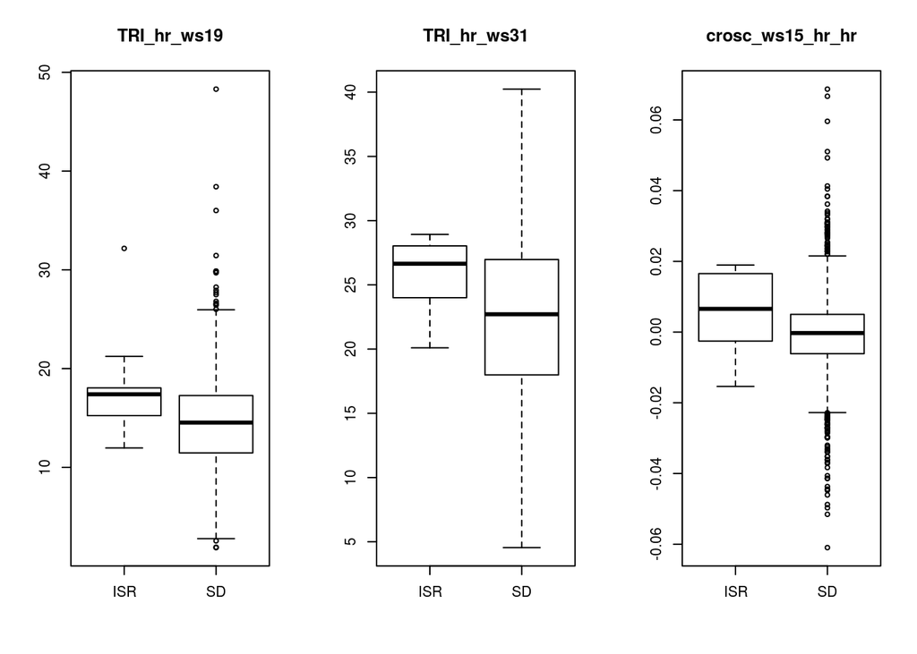

How about siliceous sedimentary rock

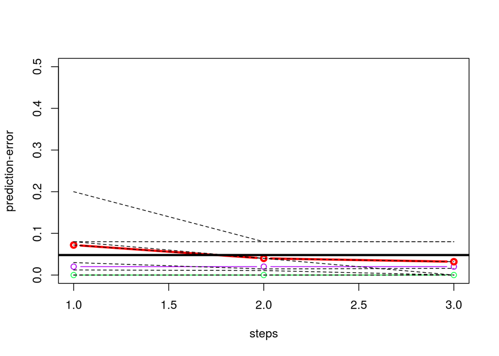

[1] “Prediction error at end is: 0.072” [2] “Prediction error at end is: 0.04” [3] “Prediction error at end is: 0.032”

| k 1 | k 2 | k 3 | k 4 | k 5 |
| --- | --- | --- | --- | --- |
| MaximalCurvature_10m | minic_DTM_50m_avg_ws3_50m | ChannelNetworkBaseLevel_10m | MaximalCurvature_10m | MaximalCurvature_10m |
| geom_hr_L3_fl10_rplipedgedensity_UE_hr_10cells_hr | profc_DTM_50m_avg_ws11_50m | Mid_Slope_Positon_50m | slope_ws5_hr_hr | geom_hr_L50m_fl1_rplipdominance_UE_hr_10cells_hr |
| geom_hr_L3_fl10_rplippatchdensity_UE_hr_10cells_hr | Relative_Slope_Position_50m | geom_hr_L3_fl1_rplipshannon_UE_hr_60cells_hr | geom_hr_L3_fl10_rplipedgedensity_UE_hr_10cells_hr | geom_hr_L3_fl1_rpliprichness_UE_hr_60cells_hr |

[1] “OBB error with all predictors of allpreds is 0.032258064516129”

|  | SD | SSR | MeanDecreaseAccuracy | MeanDecreaseGini |
| --- | --- | --- | --- | --- |
| fischerk_ws57_hr | 0.0008460 | 0.0066667 | 0.0010312 | 0.1025510 |
| Catchment_Area2_50m | 0.0006575 | 0.0010000 | 0.0006780 | 0.1579221 |
| fischerk_ws59_hr | 0.0003847 | 0.0090000 | 0.0006416 | 0.0934676 |
| fischerk_ws61_hr | 0.0004553 | 0.0026667 | 0.0005660 | 0.0543593 |
| maxic_ws15_10m | 0.0003863 | 0.0060000 | 0.0005532 | 0.0937161 |
| Total_Curvature_50m | 0.0005250 | 0.0000000 | 0.0005149 | 0.0884153 |
| vectorstrength_hr_ws41_hr | 0.0003665 | 0.0050000 | 0.0004920 | 0.0738538 |
| vectorstrength_hr_ws49_hr | 0.0004203 | 0.0020000 | 0.0004899 | 0.0586185 |
| vectorstrength_hr_ws61_hr | 0.0003841 | 0.0030000 | 0.0004655 | 0.0583844 |
| Catchment_area_50m | 0.0003532 | 0.0020000 | 0.0004352 | 0.0891864 |

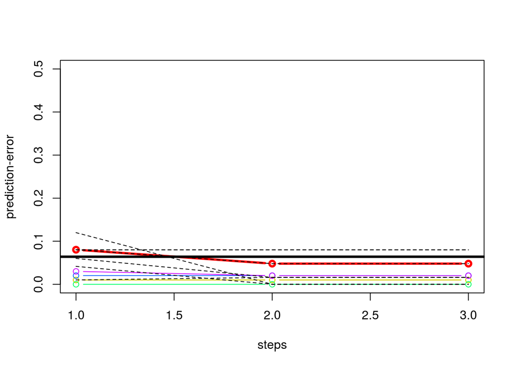

[1] “Prediction error at end is: 0.0803333333333333” [2] “Prediction error at end is: 0.048”  
[3] “Prediction error at end is: 0.048”

| k 1 | k 2 | k 3 | k 4 | k 5 |
| --- | --- | --- | --- | --- |
| fischerk_ws61_hr | geom_hr_L3_fl10_rplipmps_UE_hr_10cells_hr | geom_hr_L3_fl10_rplipedgedensity_UE_hr_60cells_hr | geom_hr_L50m_fl1_rplipdominance_UE_hr_10cells_hr | geom_hr_L50m_fl1_rplipsimpson_UE_hr_10cells_hr |
| vectorstrength_hr_ws61_hr | geom_hr_L3_fl10_rplippatchdensity_UE_hr_10cells_hr | geom_hr_L3_fl10_rplipshape_UE_hr_60cells_hr | geom_hr_L3_fl10_rplipedgedensity_UE_hr_10cells_hr | geom_hr_L50m_fl10_rplipedgedensity_UE_hr_60cells_hr |
| geom_hr_L50m_fl1_rplipsimpson_UE_hr_10cells_hr | geom_hr_L3_fl10_rplippatchnum_UE_hr_10cells_hr | geom_hr_L3_fl10_rpliprichness_UE_hr_20cells_hr | geom_hr_L3_fl10_rplipshape_UE_hr_10cells_hr | geom_hr_L50m_fl10_rplipshape_UE_hr_60cells_hr |

[1] “OBB error with all predictors of roughness is 0.0403225806451613”

|  | SD | SSR | MeanDecreaseAccuracy | MeanDecreaseGini |
| --- | --- | --- | --- | --- |
| vectorstrength_hr_ws57_hr | 0.0028286 | 0.0103333 | 0.0030895 | 0.1485242 |
| fischerk_ws59_hr | 0.0023657 | 0.0140000 | 0.0027107 | 0.1547784 |
| vectorstrength_hr_ws61_hr | 0.0022797 | 0.0130000 | 0.0026751 | 0.1328046 |
| fischerk_ws61_hr | 0.0021715 | 0.0036667 | 0.0023163 | 0.1502813 |
| fischerk_ws51_hr | 0.0020123 | 0.0130000 | 0.0023154 | 0.1357490 |
| fischerk_ws41_hr | 0.0020519 | 0.0043333 | 0.0021650 | 0.0374989 |
| vectorstrength_hr_ws59_hr | 0.0019336 | 0.0106667 | 0.0021513 | 0.0886958 |
| vectorstrength_hr_ws51_hr | 0.0021785 | 0.0000000 | 0.0021317 | 0.0862332 |
| fischerk_ws47_hr | 0.0020653 | 0.0000000 | 0.0020282 | 0.0753739 |
| vectorstrength_hr_ws53_hr | 0.0017094 | 0.0050000 | 0.0017943 | 0.1076473 |

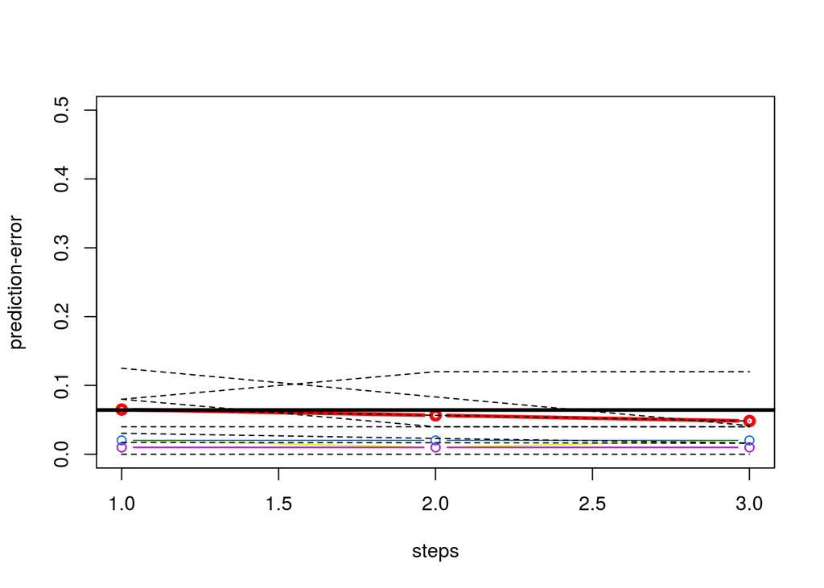

[1] “Prediction error at end is: 0.065”  
[2] “Prediction error at end is: 0.0566666666666667” [3] “Prediction error at end is: 0.0483333333333333”

| k 1 | k 2 | k 3 | k 4 | k 5 |
| --- | --- | --- | --- | --- |
| profc_DTM_50m_avg_ws11_50m | planc_ws15_hr_hr | minic_DTM_50m_avg_ws3_50m | MaximalCurvature_10m | MaximalCurvature_10m |
| maxic_ws15_10m | dtm_hr_CONVEX_r10 | maxic_ws11_10m | Plan_Curvature_hr | slope_ws5_hr_hr |
| maxic_ws11_10m | minic_ws9_hr_hr | maxic_ws15_10m | minic_ws5_hr_hr | Plan_Curvature_hr |

[1] “OBB error with all predictors of localterrain is 0.032258064516129”

|  | SD | SSR | MeanDecreaseAccuracy | MeanDecreaseGini |
| --- | --- | --- | --- | --- |
| Profile_Curvature_50m | 0.0009845 | 0.0050000 | 0.0010926 | 0.2504626 |
| profc_ws11_10m | 0.0009010 | 0.0010000 | 0.0008885 | 0.1386451 |
| planc_ws5_hr_hr | 0.0006129 | 0.0000000 | 0.0006064 | 0.0305363 |
| slope_ws13_hr_hr | 0.0006436 | -0.0010000 | 0.0005844 | 0.0166068 |
| profc_DTM_50m_avg_ws3_50m | 0.0005836 | 0.0000000 | 0.0005695 | 0.1550766 |
| slope_DTM_50m_avg_ws11_50m | 0.0004733 | 0.0020000 | 0.0005452 | 0.0644518 |
| Total_Curvature_hr | 0.0005521 | 0.0000000 | 0.0005444 | 0.0271217 |
| slope_DTM_50m_avg_ws7_50m | 0.0005167 | 0.0023333 | 0.0005423 | 0.0535315 |
| planc_ws7_hr_hr | 0.0005150 | 0.0000000 | 0.0005028 | 0.0077030 |
| slope_ws7_10m | 0.0004979 | 0.0000000 | 0.0004857 | 0.0224233 |

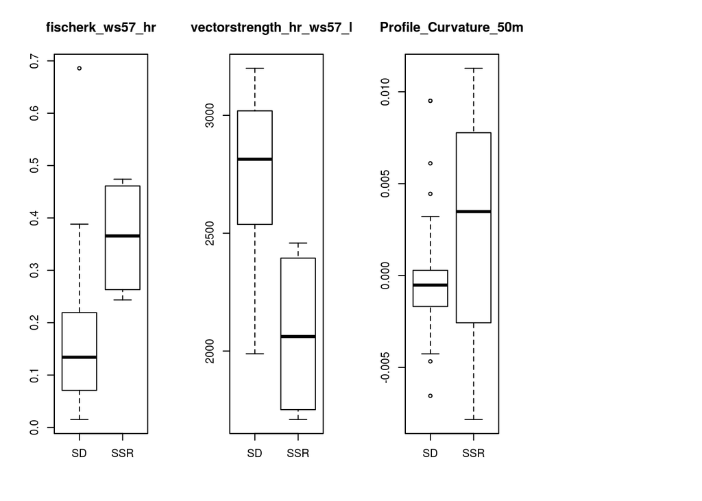

How does this compare to the differences between the units on the geological map?

[1] “OBB error with all predictors of allpreds is 0.0751173708920188”

|  | SD | SSR | MeanDecreaseAccuracy | MeanDecreaseGini |
| --- | --- | --- | --- | --- |
| Channel_Network_Base_Level_50m | 0.0039564 | 0.0208492 | 0.0055133 | 3.7401188 |
| slope_DTM_50m_avg_ws9_50m | 0.0046524 | 0.0029491 | 0.0044882 | 0.8405444 |
| slope_DTM_50m_avg_ws11_50m | 0.0040580 | 0.0041434 | 0.0040763 | 1.1867597 |
| Catchment_slope_50m | 0.0038148 | 0.0061277 | 0.0040405 | 1.1581819 |
| elev_ws15_10m | 0.0036448 | 0.0040024 | 0.0036932 | 1.3580267 |
| elev_ws5_10m | 0.0034718 | 0.0059753 | 0.0036906 | 2.0777303 |
| elev_ws3_10m | 0.0030988 | 0.0050553 | 0.0032796 | 1.4398403 |
| Texture_50m | 0.0024718 | 0.0110916 | 0.0032787 | 2.4794193 |
| Channel_Network_Base_Level_hr | 0.0027296 | 0.0058573 | 0.0030085 | 1.8929467 |
| vectorruggedness_hr_ws53 | 0.0024270 | 0.0076920 | 0.0029033 | 2.7948229 |

[1] “OBB error with all predictors of roughness is 0.08046875”

|  | SD | SSR | MeanDecreaseAccuracy | MeanDecreaseGini |
| --- | --- | --- | --- | --- |
| vectorruggedness_hr_ws59 | 0.0062514 | 0.0075708 | 0.0063988 | 4.0607850 |
| Texture_10m | 0.0049871 | 0.0093584 | 0.0054009 | 2.2668075 |
| vectorruggedness_hr_ws57 | 0.0049465 | 0.0051663 | 0.0049373 | 3.0611311 |
| vectorruggedness_hr_ws55 | 0.0041226 | 0.0075970 | 0.0044506 | 3.2215493 |
| vectorruggedness_hr_ws49 | 0.0042198 | 0.0027470 | 0.0040615 | 2.7245715 |
| Texture_50m | 0.0028481 | 0.0134598 | 0.0038455 | 3.1363320 |
| geom_hr_L50m_fl10_rplipshape_UE_hr_60cells_hr | 0.0038309 | 0.0030707 | 0.0037371 | 1.3037352 |
| geom_hr_L50m_fl10_rplipedgedensity_UE_hr_60cells_hr | 0.0039189 | 0.0012445 | 0.0036735 | 0.9993955 |
| vectorruggedness_hr_ws53 | 0.0036385 | 0.0028691 | 0.0035839 | 2.3992089 |
| TRI_hr_ws50 | 0.0041474 | -0.0020777 | 0.0035551 | 0.5181130 |

[1] “OBB error with all predictors of localterrain is 0.0952380952380952”

|  | SD | SSR | MeanDecreaseAccuracy | MeanDecreaseGini |
| --- | --- | --- | --- | --- |
| slope_DTM_50m_avg_ws9_50m | 0.0066818 | 0.0050127 | 0.0065018 | 2.836533 |
| slope_DTM_50m_avg_ws11_50m | 0.0049110 | 0.0152773 | 0.0058607 | 3.950926 |
| slope_DTM_50m_avg_ws7_50m | 0.0038373 | -0.0017509 | 0.0033144 | 1.686103 |
| minic_DTM_50m_avg_ws11_50m | 0.0031361 | -0.0009519 | 0.0027548 | 1.870869 |
| General_Curvature_50m | 0.0026125 | -0.0013622 | 0.0022520 | 2.319399 |
| slope_DTM_50m_avg_ws5_50m | 0.0027943 | -0.0039194 | 0.0021752 | 1.176446 |
| profc_DTM_50m_avg_ws11_50m | 0.0024538 | -0.0024705 | 0.0019856 | 1.319070 |
| longc_DTM_50m_avg_ws11_50m | 0.0022745 | -0.0015672 | 0.0019170 | 1.296402 |
| profc_DTM_50m_avg_ws3_50m | 0.0022746 | -0.0015842 | 0.0019059 | 1.316997 |
| planc_DTM_50m_avg_ws9_50m | 0.0020140 | -0.0006033 | 0.0017740 | 1.531047 |

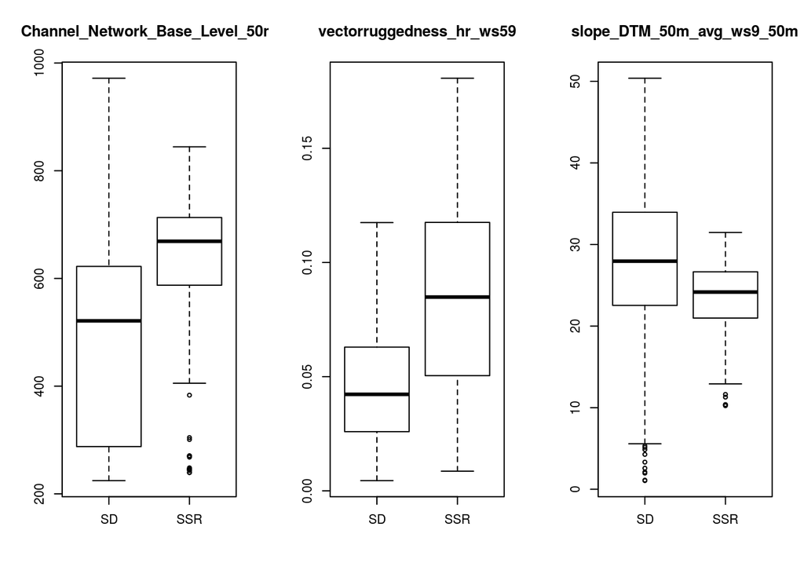